# Software Faultiness Analysis - Marco Gatto

# Project Purpose

The purpose of the project is to carry out a complete data analysis based on a dataset. In particular, the dataset Lucene provides Java-based indexing and search technology, as well as spellchecking, hit highlighting and advanced analysis/tokenization capabilities.

# Import of the dataset

In order to import the dataset, it is used the build-in function ‘read.csv’. It is also shown a preview of the first rows of the dataset.

```r
lucene <- read.csv(
  file='lucene-2.4.csv',
  head=TRUE,
  sep=',')

head(lucene)
```

|  | name | version | name.1 | wmc | dit | noc | cbo | rfc | lcom | ca | ce | npm | lcom3 | loc | dam | moa | mfa | cam | ic | cbm | amc | max_cc | avg_cc | bug |
| --- | --- | --- | --- | --- | --- | --- | --- | --- | --- | --- | --- | --- | --- | --- | --- | --- | --- | --- | --- | --- | --- | --- | --- | --- |
| 1 | lucene | 2.4 | org.apache.lucene.index.DocInverterPerThread | 5 | 2 | 0 | 19 | 18 | 0 | 8 | 15 | 4 | 0.7857143 | 84 | 0.0000000 | 7 | 0.5000000 | 0.4000000 | 0 | 0 | 14.40 | 3 | 1.20 | 1 |
| 2 | lucene | 2.4 | org.apache.lucene.search.FuzzyQuery | 10 | 3 | 0 | 13 | 41 | 7 | 1 | 12 | 9 | 0.6388889 | 286 | 0.5000000 | 0 | 0.7200000 | 0.2857143 | 2 | 6 | 27.20 | 6 | 1.40 | 3 |
| 3 | lucene | 2.4 | org.apache.lucene.search.QueryTermVector | 10 | 1 | 0 | 4 | 38 | 0 | 0 | 4 | 9 | 0.3888889 | 287 | 1.0000000 | 0 | 0.0000000 | 0.3400000 | 0 | 0 | 27.50 | 5 | 1.60 | 0 |
| 4 | lucene | 2.4 | org.apache.lucene.index.ReadOnlySegmentReader | 4 | 4 | 0 | 3 | 7 | 6 | 2 | 2 | 1 | 2.0000000 | 26 | 0.0000000 | 0 | 0.9812500 | 0.5000000 | 2 | 3 | 5.50 | 3 | 1.25 | 0 |
| 5 | lucene | 2.4 | org.apache.lucene.index.DirectoryIndexReader | 25 | 2 | 2 | 20 | 82 | 160 | 5 | 18 | 8 | 0.8819444 | 596 | 0.8333333 | 5 | 0.7684211 | 0.1979167 | 2 | 8 | 22.36 | 3 | 1.08 | 10 |
| 6 | lucene | 2.4 | org.apache.lucene.index.DocFieldConsumerPerThread | 5 | 1 | 3 | 13 | 6 | 10 | 10 | 3 | 0 | 2.0000000 | 8 | 0.0000000 | 0 | 0.0000000 | 0.6000000 | 0 | 0 | 0.60 | 1 | 0.80 | 0 |

The dataset is composed by 340 rows and 24 columns.

```r
cat("Number of columns:", length(lucene))
```

```
Number of columns: 24
```

```r
cat("Number of rows:", length(lucene[[1]]))
```

```
Number of rows: 340
```

The names of the columns are shown below.

```r
colnames(lucene)
```

```
 [1] "name"    "version" "name.1"  "wmc"     "dit"     "noc"     "cbo"     "rfc"     "lcom"    "ca"
[11] "ce"      "npm"     "lcom3"   "loc"     "dam"     "moa"     "mfa"     "cam"     "ic"      "cbm"
[21] "amc"     "max_cc"  "avg_cc"  "bug"
```

# Selection and visualization of the dependent variable

The dependent variable must be related to the software faultiness. Looking at the available columns in the dataset, the ‘bug’ column is the only one that meets this requirement. In particular, it represents the number of defects reported in the analyzed artifacts.

```r
sw_fault <- lucene$bug

head(sw_fault)
```

```
[1]  1  3  0  0 10  0
```

Instead of looking at the single values of the variable, it is possible to show the histogram representing the their frequencies. In this way, it is possible to see whether the data are mostly focused around some values.

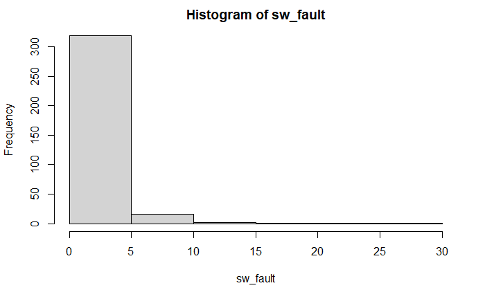

```r
hist(sw_fault)
```

It is also possible to show the histogram with different breaks.

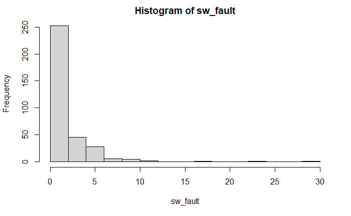

```r
hist(sw_fault, breaks=15)
```

In order to have a better idea of how the data are distributed, it is also possible to show a boxplot.

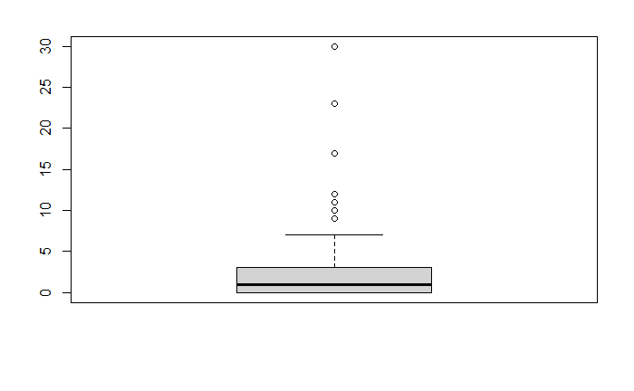

```r
boxplot(sw_fault)
```

# Selection and visualization of the independent variables

The independent variables must be taken among the columns available in the dataset. In particular, it has been chosen to take into consideration the following variables:

- Lines Of Code (LOC)
- Average Method Complexity (AMC)
- Measure Of Aggregation (MOA)
- Lack of COhesion in Methods (LCOM)

The first two variables take into account the dimension or the complexity of the artifacts. The last two variables take into account the class fields of the artifacts. A more detailed description is performed below.

## Selection and visualization of the independent variables - LOC

The variable LOC represents the number of lines of code based on the Java binary code. In particular, it is the sum of number of fields, number of methods and number of instructions in every method of the investigated class.

```r
loc <- lucene$loc

head(loc)
```

```
[1]  84 286 287  26 596   8
```

The histogram and the boxplot of this variable are shown below.

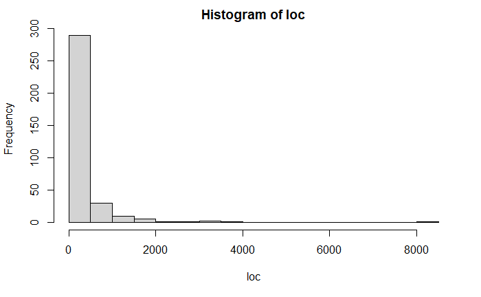

```r
hist(loc, breaks=15)
```

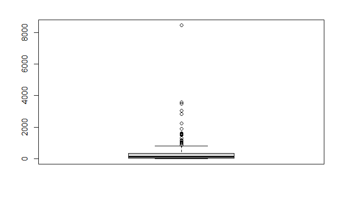

```r
boxplot(loc)
```

Since LOC is an independent variable, it is also possible to plot some diagrams that show the distribution of the dependent variable with respect to the values of the independent variable. In particular, a scatterplot and a boxplot are shown below.

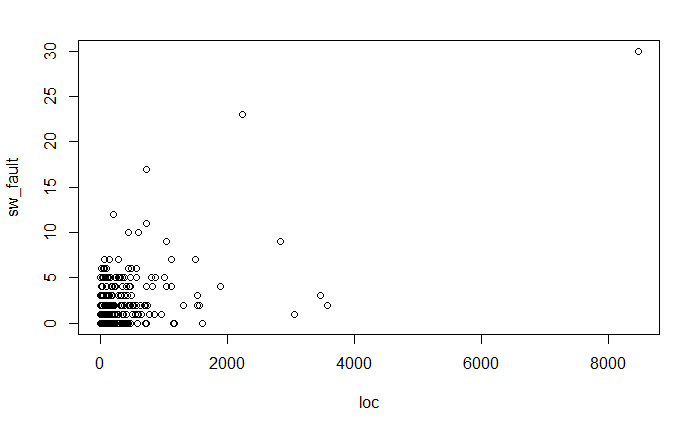

```r
plot(loc, sw_fault)
```

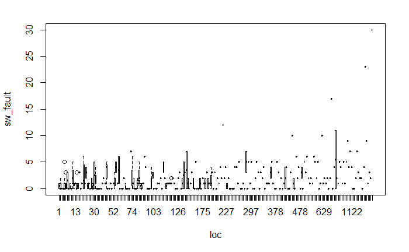

```r
boxplot(sw_fault~loc)
```

## Selection and visualization of the independent variables - AMC

The variable AMC measures the average method size for each class. Size of a method is equal to the number of Java binary codes in the method.

```r
amc <- lucene$amc

head(amc)
```

```
[1] 14.40 27.20 27.50  5.50 22.36  0.60
```

The histogram and the boxplot of this variable are shown below.

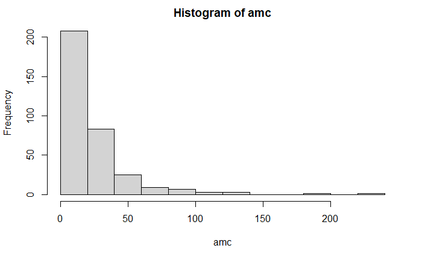

```r
hist(amc, breaks=10)
```

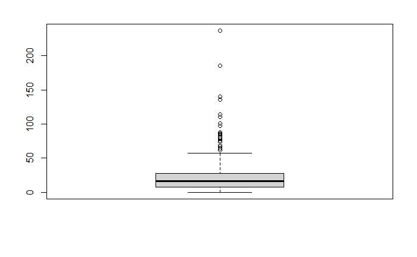

```r
boxplot(amc)
```

Since AMC is an independent variable, it is also possible to plot some diagrams that show the distribution of the dependent variable with respect to the values of the independent variable. In particular, a scatterplot and a boxplot are shown below.

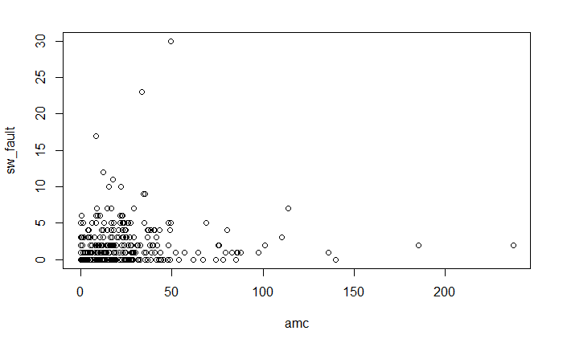

```r
plot(amc, sw_fault)
```

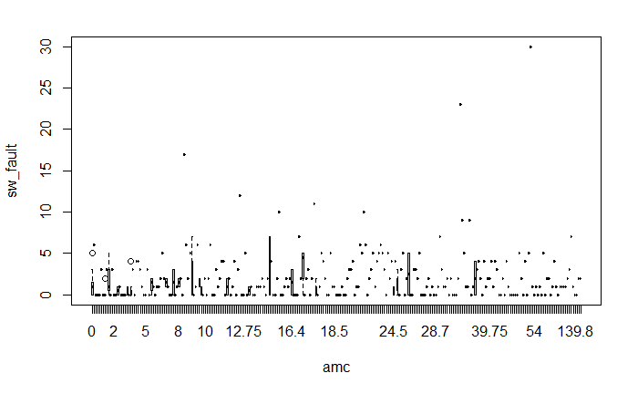

```r
boxplot(sw_fault~amc)
```

## Selection and visualization of the independent variables - MOA

The variable MOA measures the extent of the part-whole relationship, realized by using attributes. The metric is a count of the number of class fields whose types are user defined classes.

```r
moa <- lucene$moa

head(moa)
```

```
[1] 7 0 0 0 5 0
```

The histogram and the boxplot of this variable are shown below.

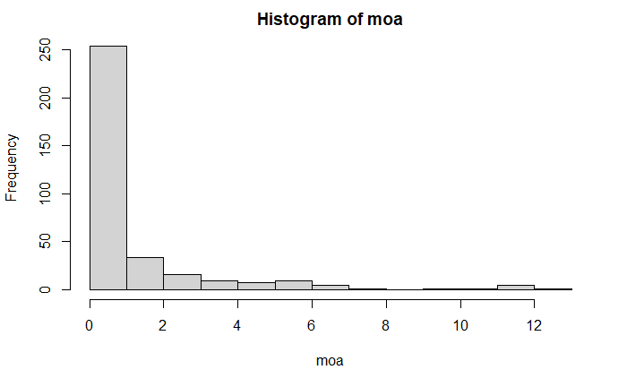

```r
hist(moa)
```

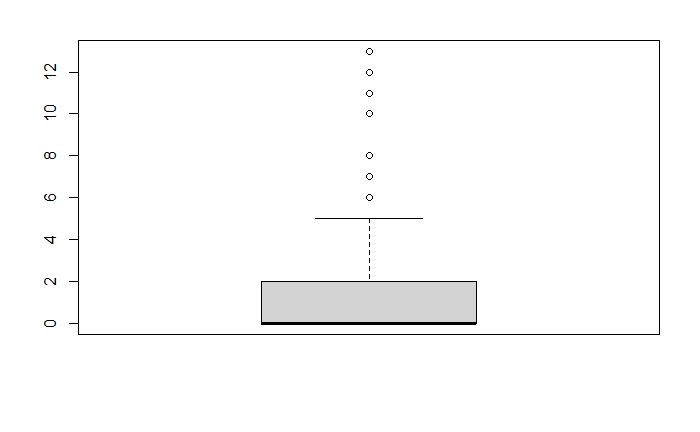

```r
boxplot(moa)
```

Since MOA is an independent variable, it is also possible to plot some diagrams that show the distribution of the dependent variable with respect to the values of the independent variable. In particular, a scatterplot and a boxplot are shown below.

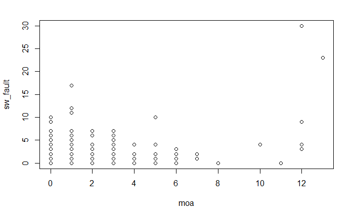

```r
plot(moa, sw_fault)
```

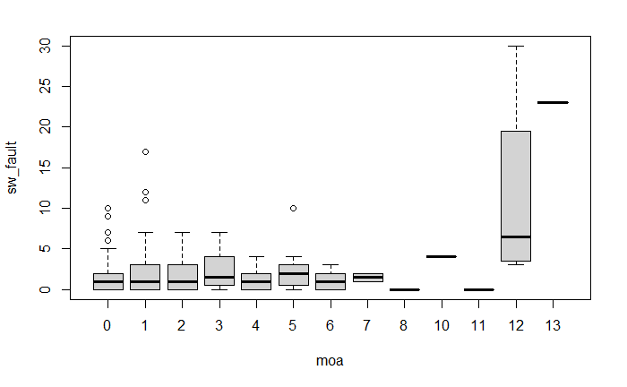

```r
boxplot(sw_fault~moa)
```

## Selection and visualization of the independent variables - LCOM

The variable LCOM counts the sets of methods in a class that are not related through the sharing of some of the class fields. In particular, it is calculated by subtracting from the number of method pairs that do not share a field access the number of method pairs that do.

```r
lcom <- lucene$lcom

head(lcom)
```

```
[1]   0   7   0   6 160  10
```

The histogram and the boxplot of this variable are shown below.

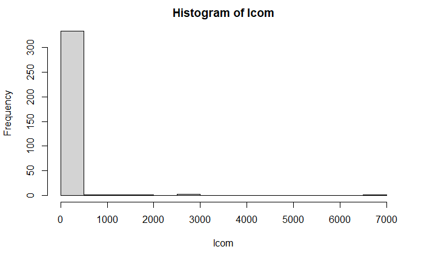

```r
hist(lcom, breaks=10)
```

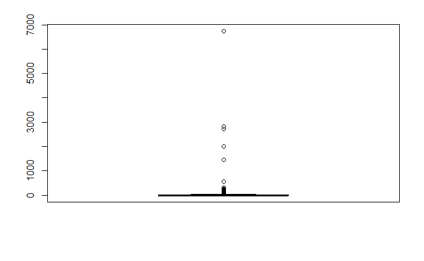

```r
boxplot(lcom)
```

Since LCOM is an independent variable, it is also possible to plot some diagrams that show the distribution of the dependent variable with respect to the values of the independent variable. In particular, a scatterplot and a boxplot are shown below.

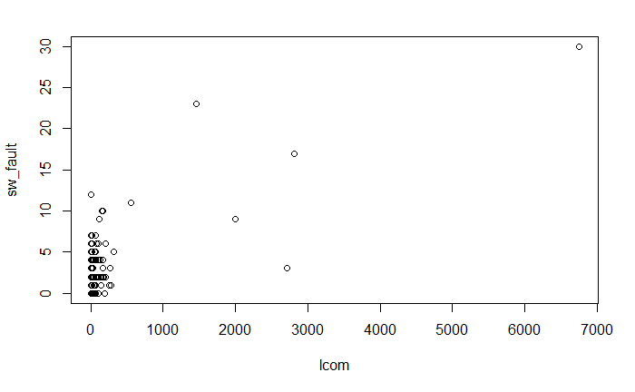

```r
plot(lcom, sw_fault)
```

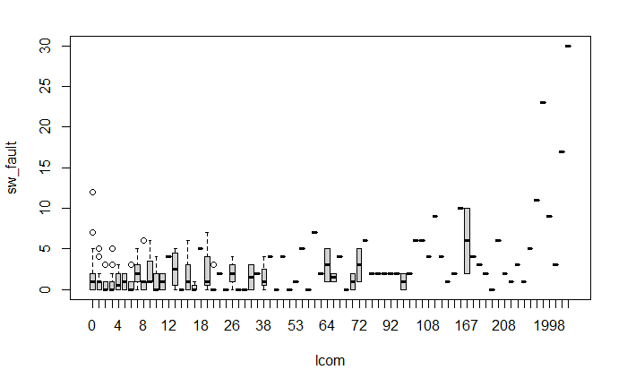

```r
boxplot(sw_fault~lcom)
```

# Descriptive Statistics

Descriptive statistics are used to quantitatively describe or summarize features from a collection of information.

In order to get a significant set of descriptive statistics, it should contain indicators that are able to provide information about the cardinality of the dataset, the central tendency indicator and the dispersion indicators. Since none of the considered variables is neither a nominal nor an ordinal scale, the set of descriptive statistics computed on the considered variables contains:

- Number of samples
- Minimum and Maximum values
- Median
- Mean
- Standard Deviation

The first step concerns the definition of a function that computes the descriptive statistics on a specific variable and then groups them into a table.

```r
descrStatsNames <- c('Samples Nr','Min','Max','Median','Mean','Std. Dev')

descriptive.statistics <- function(var) {
  samplesNumber <- length(var)
  min <- min(var)
  max <- max(var)
  median <- median(var)
  mean <- mean(var)
  stdDev <- sd(var)
  matrix <- matrix(c(samplesNumber, min, max, median, mean, stdDev), byrow=TRUE)
  rownames(matrix) <- descrStatsNames
  return (as.table(matrix))
}
```

This function will be used to compute the descriptive statistics for all the considered variables.

## Descriptive Statistics - Software Faultiness

```r
sw_fault_DescrStats <- descriptive.statistics(sw_fault)
colnames(sw_fault_DescrStats) <- c('Sw_Fault')
sw_fault_DescrStats
```

```
             Sw_Fault
Samples Nr 340.000000
Min          0.000000
Max         30.000000
Median       1.000000
Mean         1.858824
Std. Dev     2.975427
```

## Descriptive Statistics - LOC

```r
loc_DescrStats <- descriptive.statistics(loc)
colnames(loc_DescrStats) <- c('LOC')
loc_DescrStats
```

```
                 LOC
Samples Nr  340.0000
Min           1.0000
Max        8474.0000
Median      121.5000
Mean        302.5265
Std. Dev    639.3336
```

## Descriptive Statistics - AMC

```r
amc_DescrStats <- descriptive.statistics(amc)
colnames(amc_DescrStats) <- c('AMC')
amc_DescrStats
```

```
                 AMC
Samples Nr 340.00000
Min          0.00000
Max        237.20000
Median      16.33889
Mean        23.04441
Std. Dev    27.15896
```

## Descriptive Statistics - MOA

```r
moa_DescrStats <- descriptive.statistics(moa)
colnames(moa_DescrStats) <- c('MOA')
moa_DescrStats
```

```
                  MOA
Samples Nr 340.000000
Min          0.000000
Max         13.000000
Median       0.000000
Mean         1.288235
Std. Dev     2.214029
```

## Descriptive Statistics - LCOM

```r
lcom_DescrStats <- descriptive.statistics(lcom)
colnames(lcom_DescrStats) <- c('LCOM')
lcom_DescrStats
```

```
                 LCOM
Samples Nr  340.00000
Min           0.00000
Max        6747.00000
Median        3.00000
Mean         68.72353
Std. Dev    442.98452
```

## Descriptive Statistics - Results

The descriptive statistics computed on all the considered variables can be reported into a single table.

```r
cbind(sw_fault_DescrStats, loc_DescrStats, amc_DescrStats, moa_DescrStats, lcom_DescrStats)
```

```
             Sw_Fault       LOC       AMC        MOA       LCOM
Samples Nr 340.000000  340.0000 340.00000 340.000000  340.00000
Min          0.000000    1.0000   0.00000   0.000000    0.00000
Max         30.000000 8474.0000 237.20000  13.000000 6747.00000
Median       1.000000  121.5000  16.33889   0.000000    3.00000
Mean         1.858824  302.5265  23.04441   1.288235   68.72353
Std. Dev     2.975427  639.3336  27.15896   2.214029  442.98452
```

# Univariate statistically-significant model - OLS

The Ordinary Least Square (OLS) regression is a statistical technique used for the analysis and modelling of linear relationships between a dependent variable and one or more independent variables. If the relationship between two variables appears to be linear, then a straight line can be fit to the data in order to model the relationship.

## Univariate statistically-significant model - OLS - Software Faultiness vs LOC

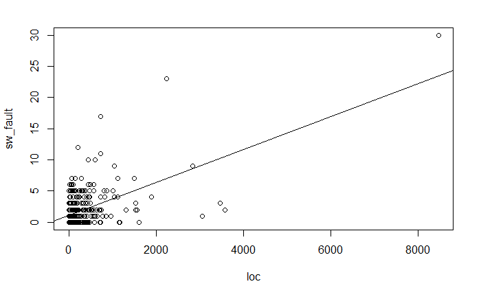

```r
sw_faultVSloc <- lm(sw_fault~loc)

plot(loc, sw_fault)
abline(sw_faultVSloc)
```

Before the application of the OLS technique, it is needed to verify whether its assumptions are met. In particular, the assumptions impose that the distribution of the two variables must be linear. This step is particularly important because it can be used to assess whether the obtained model can be considered statistically-significant.

In order to check whether the assumptions of the OLS technique are met, a correlation test can be used. In particular, a correlation test is a technique that is used to evaluate the association between two or more variables. The result of the application of a correlation test is a coefficient, that is a numeric value that measure the degree of association between the variables. There are several, well-known correlation coefficients that can be used to evaluate the association between variables:

- Pearson’s R: it is used to measure the degree of correlation between two variables. It is computed as the covariance of the two variables, divided by the product of their standard deviations. Its values are always between -1 and +1, where -1 implies a perfect negative correlation, 0 implies the absence of correlation and +1 implies a perfect positive correlation.
- Spearman’s rho: it is Pearson’s R applied to the ranked values rather than to the raw data. Even in this case, its values range between -1 and +1.
- Kendall’s tau: it is used to measure the degree of correlation between two variables. Even in this case, its values range between -1 and +1. However, Kendall’s tau is more robust and efficient than Spearman’s rho, and it is usually preferred when there are small samples and some outliers. Kendall’s tau is generally smaller than Spearman’s rho.

In order to check whether two variables are linearly dependent, it is also possible to use the Shapiro-Wilk’s test of normality. The null hypothesis of the test is that the data are normally distributed, while the alternative hypothesis is that the data are not normally distributed. The results of the Shapiro-Wilk test are the W coefficient and the p-value. In particular, if the p-value is less than 0.05, then the null hypothesis is rejected and there is the evidence that the data are not normally distributed. However, if the p-value is greater than 0.05, then the null hypothesis cannot be rejected and there is the evidence that the data are normally distributed.

### Check of the assumptions

The first step concerns the definition of a function that computes the main correlation coefficients over two variables.

```r
corrCoeffNames <- c('Pearson\'s R',
                    'Spearman\'s Rho',
                    'Kendall\'s Tau',
                    'Shapiro-Wilk p-value')

correlation.coefficients <- function(x,y,ols_model) {
  orig_pearson <- cor.test(x, y,
                          alternative="greater",
                          method="pearson")
  orig_r <- orig_pearson$estimate
  print(orig_pearson)

  orig_spearman <- cor.test(y, x,
                            alternative="two.sided",
                            method="spearman",
                            exact=FALSE)
  orig_rho <- orig_spearman$estimate
  print(orig_spearman)

  orig_kendall <- cor.test(y, x,
                           alternative="greater",
                           method="kendall")
  orig_tau <- orig_kendall$estimate
  print(orig_kendall)

  orig_shapiro <- shapiro.test(ols_model$residuals)
  orig_pvalue <- orig_shapiro$p.value
  print(orig_shapiro)

  matrix <- matrix(c(orig_r, orig_rho, orig_tau, orig_pvalue), byrow=TRUE)
  rownames(matrix) <- corrCoeffNames
  return (as.table(matrix))
}
```

```r
orig_corrCoeff <- correlation.coefficients(loc, sw_fault, sw_faultVSloc)
```

```
    Pearson's product-moment correlation

data:  x and y
t = 12.653, df = 338, p-value < 2.2e-16
alternative hypothesis: true correlation is greater than 0
95 percent confidence interval:
 0.5030562 1.0000000
sample estimates:
      cor
0.5669322


    Spearman's rank correlation rho

data:  y and x
S = 4238053, p-value = 2.047e-11
alternative hypothesis: true rho is not equal to 0
sample estimates:
      rho
0.3530293


    Kendall's rank correlation tau

data:  y and x
z = 6.6459, p-value = 1.506e-11
alternative hypothesis: true tau is greater than 0
sample estimates:
      tau
0.2654379


    Shapiro-Wilk normality test

data:  ols_model$residuals
W = 0.82309, p-value < 2.2e-16
```

```r
colnames(orig_corrCoeff) <- c('SwFaultVSLOC')
orig_corrCoeff
```

```
                     SwFaultVSLOC
Pearson's R          5.669322e-01
Spearman's Rho       3.530293e-01
Kendall's Tau        2.654379e-01
Shapiro-Wilk p-value 5.090669e-19
```

According to the obtained results, the Pearson’s R coefficient shows a slight degree of correlation between the two variables. Even if their values are less significant, both the Spearman’s rho and the Kendall’s tau coefficients show a slight degree of correlation. However, the p-value computed by the Shapiro-Wilk test strongly rejects the normality of the data.

### Data transformation

Since it is not possible to establish whether the data are effectively linearly dependent, it can be useful to try to apply some data transformation techniques and then check again whether the assumptions of the OLS model are met by the new data. In particular, it is possible to adopt two different approaches.

### Data transformation - Logarithmic transformation

This technique implies that both the dependent and the independent variables are replaced by their logarithm. In particular, in order to avoid the creation of negative values, the data will be transformed according to the formula
$$var' = log(1 + var)$$

```r
log_sw_fault <- log(1+sw_fault)
log_loc <- log(1+loc)

log_sw_faultVSloc <- lm(log_sw_fault~log_loc)
```

```r
log_corrCoeff <- correlation.coefficients(log_loc, log_sw_fault, log_sw_faultVSloc)
```

```
    Pearson's product-moment correlation

data:  x and y
t = 7.4936, df = 338, p-value = 2.959e-13
alternative hypothesis: true correlation is greater than 0
95 percent confidence interval:
 0.2981445 1.0000000
sample estimates:
    cor
0.37745


    Spearman's rank correlation rho

data:  y and x
S = 4238053, p-value = 2.047e-11
alternative hypothesis: true rho is not equal to 0
sample estimates:
      rho
0.3530293


    Kendall's rank correlation tau

data:  y and x
z = 6.6459, p-value = 1.506e-11
alternative hypothesis: true tau is greater than 0
sample estimates:
      tau
0.2654379


    Shapiro-Wilk normality test

data:  ols_model$residuals
W = 0.97089, p-value = 2.421e-06
```

```r
colnames(log_corrCoeff) <- c('Log_SwFaultVSLOC')
log_corrCoeff
```

```
                     Log_SwFaultVSLOC
Pearson's R              3.774500e-01
Spearman's Rho           3.530293e-01
Kendall's Tau            2.654379e-01
Shapiro-Wilk p-value     2.420526e-06
```

According to the obtained results and with the results obtained on the original data, the results of both the Spearman’s rho and the Kendall’s tau are not changed and the Pearson’s R is worse. Furthermore, the p-value computed by the Shapiro-Wilk test is still less than 0.05. So, this transformation did not work in this situation.

It is also possible to graphically check the differences between the two OLS lines of regression.

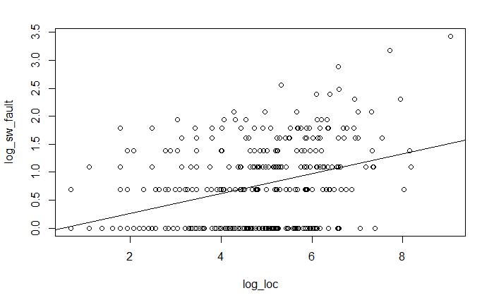

```r
plot(log_loc, log_sw_fault)
abline(log_sw_faultVSloc)
```

### Data transformation - Outliers Removal

Outliers are data-points with a heavy influence for the regression model. In particular, they can lead to the creation of incorrect or useless models. Outliers can be caused by corrupted data or rare statistical fluctuations. So, it can be particularly interesting to investigate the reasons that brought to their values.

In order to eliminate the outliers, it is important to adopt an iterative and automatic approach. In particular, one of the most important considerations that need to be taken into account is the evaluation of the model after the removal of each outlier.

The metric used to evaluate the influence of a data-point for the regression model is the Cook’s distance.

```r
cooksDistances <- cooks.distance(sw_faultVSloc)
head(cooksDistances)
```

```
           1            2            3            4            5            6
2.186461e-05 3.448504e-04 8.117825e-04 3.722003e-04 1.615958e-02 3.488561e-04
```

A data-point is considered to be an outlier when its Cook’s distance is greater than a fixed threshold. In particular, it has been chosen to evaluate the results obtained by using two different threshold values. In the first case, the threshold is set to 4/L, where L is the number of samples. In the second case, the threshold is set to 1.

```r
sum(cooksDistances > 4/length(cooksDistances))
```

```
[1] 14
```

```r
sum(cooksDistances > 1)
```

```
[1] 1
```

Since it is preferable to remove the fewest number of data-points, the case in which the threshold equals 1 is analyzed as first.

### Data transformation - Outliers Removal - Threshold = 1

The first step of this procedure concerns the definition of a function that iteratively removes the outliers from the data.

```r
removeOutliersCook1 <- function(x,y) {
  done = FALSE
  while ( !done ) {
    model = lm(y ~ x)
    cooksDistances <- cooks.distance(model)
    maxCooksDistance = max(cooksDistances)
    l = length(y)
    if(maxCooksDistance < 1) { done = TRUE; break; }
    removeNext = which.max(cooksDistances)
    y = y[-c(removeNext)]
    x = x[-c(removeNext)]
  }
  return (list(x,y))
}
```

Then, the function is called on the variables LOC and Software Faultiness.

```r
nonOutliersCook1 <- removeOutliersCook1(loc, sw_fault)
```

In order to make the code more clear, two new variables are created.

```r
nonOutliersCook1_loc <- nonOutliersCook1[[1]]
nonOutliersCook1_sw_fault <- nonOutliersCook1[[2]]
```

Before the correlation coefficient are computed on the new data, it is important to check how many data-points has been removed.

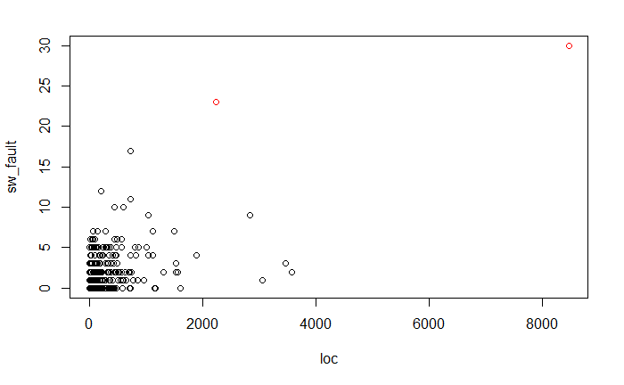

```r
plot(loc, sw_fault, col="red")
points(nonOutliersCook1_loc, nonOutliersCook1_sw_fault, col="black")
```

The model is finally re-created and the OLS assumptions are checked on the data with the outliers removed.

```r
nonOutliersCook1_sw_faultsVSloc <- lm(nonOutliersCook1_sw_fault~nonOutliersCook1_loc)

nonOutliersCook1_corrCoeff <- correlation.coefficients(nonOutliersCook1_loc,
                                                       nonOutliersCook1_sw_fault,
                                                       nonOutliersCook1_sw_faultsVSloc)
```

```
    Pearson's product-moment correlation

data:  x and y
t = 5.1536, df = 336, p-value = 2.184e-07
alternative hypothesis: true correlation is greater than 0
95 percent confidence interval:
 0.1855323 1.0000000
sample estimates:
      cor
0.2706584


    Spearman's rank correlation rho

data:  y and x
S = 4240386, p-value = 1.177e-10
alternative hypothesis: true rho is not equal to 0
sample estimates:
      rho
0.3411138


    Kendall's rank correlation tau

data:  y and x
z = 6.3741, p-value = 9.201e-11
alternative hypothesis: true tau is greater than 0
sample estimates:
      tau
0.2556181


    Shapiro-Wilk normality test

data:  ols_model$residuals
W = 0.81022, p-value < 2.2e-16
```

```r
colnames(nonOutliersCook1_corrCoeff) <- c('NonOutCook1_SwFaultVSLOC')
nonOutliersCook1_corrCoeff
```

```
                     NonOutCook1_SwFaultVSLOC
Pearson's R                      2.706584e-01
Spearman's Rho                   3.411138e-01
Kendall's Tau                    2.556181e-01
Shapiro-Wilk p-value             1.305957e-19
```

Comparing the obtained results with the ones obtained on the original data, all the coefficients show worse results. In particular, the p-value computed by the Shapiro-Wilk test is less than 0.05. So, this transformation did not work in this situation.

It is also possible to graphically check the differences between the two OLS lines of regression.

```r
plot(loc, sw_fault)
abline(sw_faultVSloc)
```

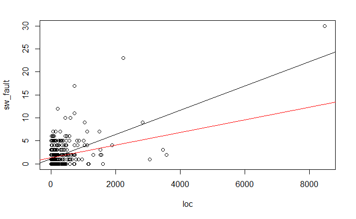

```r
abline(nonOutliersCook1_sw_faultsVSloc, col="red")
```

### Data transformation - Outliers Removal - Threshold = 4/L

Even in this case, the first step of this procedure concerns the definition of a function that iteratively removes the outliers from the data.

```r
removeOutliersCook4l <- function(x,y) {
  done = FALSE
  while ( !done ) {
    model = lm(y ~ x)
    cooksDistances <- cooks.distance(model)
    maxCooksDistance = max(cooksDistances)
    l = length(y)
    if(maxCooksDistance < 4/l) { done = TRUE; break; }
    removeNext = which.max(cooksDistances)
    y = y[-c(removeNext)]
    x = x[-c(removeNext)]
  }
  return (list(x,y))
}
```

Then, the function is called on the variables LOC and Software Faultiness.

```r
nonOutliersCook4l <- removeOutliersCook4l(loc, sw_fault)
```

In order to make the code more clear, two new variables are created.

```r
nonOutliersCook4l_loc <- nonOutliersCook4l[[1]]
nonOutliersCook4l_sw_fault <- nonOutliersCook4l[[2]]
```

Before the correlation coefficient are computed on the new data, it is important to check how many data-points has been removed.

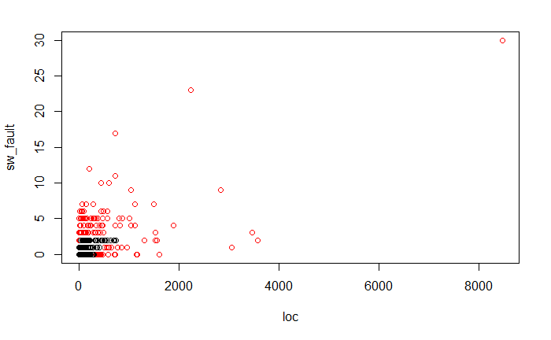

```r
plot(loc, sw_fault, col="red")
points(nonOutliersCook4l_loc, nonOutliersCook4l_sw_fault, col="black")
```

In particular, in this case the scatterplot shows that a very huge number of data-points has been considered outliers and has been removed from the original data. This is a possible reason to support the choice to consider this model as not statistically-significant.

```r
cat("Data-points in the original data:",
    length(sw_fault))
```

```
Data-points in the original data: 340
```

```r
cat("Data-points removed from the original data:",
    length(sw_fault) - length(nonOutliersCook4l_sw_fault))
```

```
Data-points removed from the original data: 127
```

The model is finally re-created and the OLS assumptions are checked on the data with the outliers removed.

```r
nonOutliersCook4l_sw_faultsVSloc <- lm(nonOutliersCook4l_sw_fault~nonOutliersCook4l_loc)

nonOutliersCook4l_corrCoeff <- correlation.coefficients(nonOutliersCook4l_loc,
                                                        nonOutliersCook4l_sw_fault,
                                                        nonOutliersCook4l_sw_faultsVSloc)
```

```
    Pearson's product-moment correlation

data:  x and y
t = 7.9569, df = 211, p-value = 5.333e-14
alternative hypothesis: true correlation is greater than 0
95 percent confidence interval:
 0.3884948 1.0000000
sample estimates:
      cor
0.4804212


    Spearman's rank correlation rho

data:  y and x
S = 965373, p-value = 1.293e-09
alternative hypothesis: true rho is not equal to 0
sample estimates:
      rho
0.4005996


    Kendall's rank correlation tau

data:  y and x
z = 5.936, p-value = 1.46e-09
alternative hypothesis: true tau is greater than 0
sample estimates:
      tau
0.3194112


    Shapiro-Wilk normality test

data:  ols_model$residuals
W = 0.91724, p-value = 1.533e-09
```

```r
colnames(nonOutliersCook4l_corrCoeff) <- c('NonOutCook4l_SwFaultVSLOC')
nonOutliersCook4l_corrCoeff
```

```
                     NonOutCook4l_SwFaultVSLOC
Pearson's R                       4.804212e-01
Spearman's Rho                    4.005996e-01
Kendall's Tau                     3.194112e-01
Shapiro-Wilk p-value              1.533034e-09
```

Comparing the obtained results with the ones obtained on the original data, the Pearson’s R coefficient is slightly decreased, but both the Spearman’s rho and the Kendall’s tau are slightly increased. However, the p-value computed by the Shapiro-Wilk test is still less than 0.05. So, this transformation did not work in this situation.

It is also possible to graphically check the differences between the two OLS lines of regression.

```r
plot(loc, sw_fault)
abline(sw_faultVSloc)
```

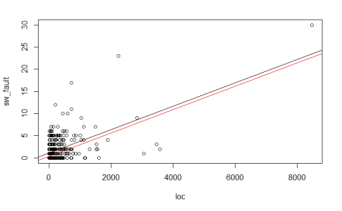

```r
abline(nonOutliersCook4l_sw_faultsVSloc, col="red")
```

### Final considerations

The application of the OLS technique on the variables LOC and Software Faultiness is not possible, because these two variables are not linearly dependent.

In particular, it is possible to report the main coefficient that evaluate the linear dependency of these two variables over the different analysis performed.

```r
cbind(orig_corrCoeff, log_corrCoeff, nonOutliersCook1_corrCoeff, nonOutliersCook4l_corrCoeff)
```

```
                     SwFaultVSLOC Log_SwFaultVSLOC NonOutCook1_SwFaultVSLOC NonOutCook4l_SwFaultVSLOC
Pearson's R          5.669322e-01     3.774500e-01             2.706584e-01              4.804212e-01
Spearman's Rho       3.530293e-01     3.530293e-01             3.411138e-01              4.005996e-01
Kendall's Tau        2.654379e-01     2.654379e-01             2.556181e-01              3.194112e-01
Shapiro-Wilk p-value 5.090669e-19     2.420526e-06             1.305957e-19              1.533034e-09
```

Looking at the above table, it is possible to state that only the original data show a slight degree of correlation. In particular, all the data transformation techniques reduce the degree of linear dependency among the two variables.

## Univariate statistically-significant model - OLS - Software Faultiness vs AMC

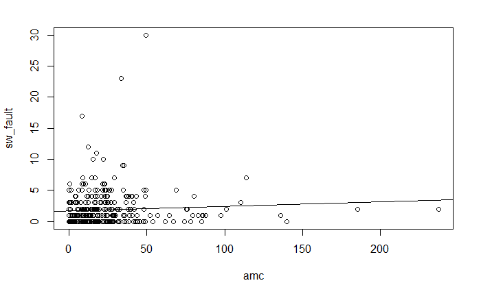

```r
sw_faultVSamc <- lm(sw_fault~amc)

plot(amc, sw_fault)
abline(sw_faultVSamc)
```

The steps performed to evaluate the results of the OLS technique applied to the variables Software Faultiness and AMC are the same performed in the previous analysis.

### Check of the assumptions

```r
orig_corrCoeff <- correlation.coefficients(amc, sw_fault, sw_faultVSamc)
```

```
    Pearson's product-moment correlation

data:  x and y
t = 1.2337, df = 338, p-value = 0.1091
alternative hypothesis: true correlation is greater than 0
95 percent confidence interval:
 -0.02254027  1.00000000
sample estimates:
       cor
0.06695646


    Spearman's rank correlation rho

data:  y and x
S = 5435390, p-value = 0.001629
alternative hypothesis: true rho is not equal to 0
sample estimates:
      rho
0.1702467


    Kendall's rank correlation tau

data:  y and x
z = 3.1334, p-value = 0.0008641
alternative hypothesis: true tau is greater than 0
sample estimates:
      tau
0.1251595


    Shapiro-Wilk normality test

data:  ols_model$residuals
W = 0.61835, p-value < 2.2e-16
```

```r
colnames(orig_corrCoeff) <- c('SwFaultVSAMC')
orig_corrCoeff
```

```
                     SwFaultVSAMC
Pearson's R          6.695646e-02
Spearman's Rho       1.702467e-01
Kendall's Tau        1.251595e-01
Shapiro-Wilk p-value 8.840700e-27
```

According to the obtained results, all the coefficients show bad results. In particular, the p-value computed by the Shapiro-Wilk test is less than 0.05.

### Data transformation - Logarithmic transformation

```r
log_sw_fault <- log(1+sw_fault)
log_amc <- log(1+amc)

log_sw_faultVSamc <- lm(log_sw_fault~log_amc)
```

```r
log_corrCoeff <- correlation.coefficients(log_amc, log_sw_fault, log_sw_faultVSamc)
```

```
    Pearson's product-moment correlation

data:  x and y
t = 3.4151, df = 338, p-value = 0.0003576
alternative hypothesis: true correlation is greater than 0
95 percent confidence interval:
 0.0948165 1.0000000
sample estimates:
      cor
0.1826309


    Spearman's rank correlation rho

data:  y and x
S = 5435390, p-value = 0.001629
alternative hypothesis: true rho is not equal to 0
sample estimates:
      rho
0.1702467


    Kendall's rank correlation tau

data:  y and x
z = 3.1334, p-value = 0.0008641
alternative hypothesis: true tau is greater than 0
sample estimates:
      tau
0.1251595


    Shapiro-Wilk normality test

data:  ols_model$residuals
W = 0.93211, p-value = 2.491e-11
```

```r
colnames(log_corrCoeff) <- c('Log_SwFaultVSAMC')
log_corrCoeff
```

```
                     Log_SwFaultVSAMC
Pearson's R              1.826309e-01
Spearman's Rho           1.702467e-01
Kendall's Tau            1.251595e-01
Shapiro-Wilk p-value     2.491235e-11
```

According to the obtained results and with the results obtained on the original data, the results of both the Spearman’s rho and the Kendall’s tau are not changed and the Pearson’s R is slightly increased. However, the p-value computed by the Shapiro-Wilk test is still less than 0.05. So, this transformation did not work in this situation.

It is also possible to graphically check that the data are not linearly dependent.

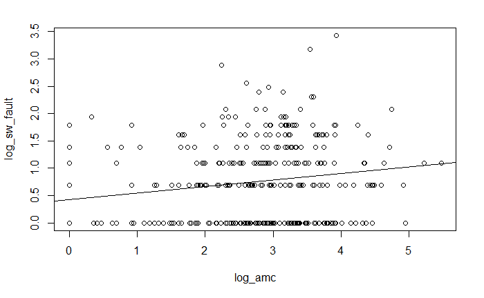

```r
plot(log_amc, log_sw_fault)
abline(log_sw_faultVSamc)
```

### Data transformation - Outliers Removal

```r
cooksDistances <- cooks.distance(sw_faultVSamc)
sum(cooksDistances > 4/length(cooksDistances))
```

```
[1] 10
```

```r
sum(cooksDistances > 1)
```

```
[1] 0
```

Since there are no data-points with a Cook’s distance greater than 1, this case is not analyzed.

### Data transformation - Outliers Removal - Threshold = 4/L

In order to remove the outliers according to a threshold value equal to 4/L, the same function defined before is used.

```r
nonOutliersCook4l <- removeOutliersCook4l(amc, sw_fault)
```

In order to make the code more clear, two new variables are created.

```r
nonOutliersCook4l_amc <- nonOutliersCook4l[[1]]
nonOutliersCook4l_sw_fault <- nonOutliersCook4l[[2]]
```

Before the correlation coefficient are computed on the new data, it is important to check how many data-points has been removed.

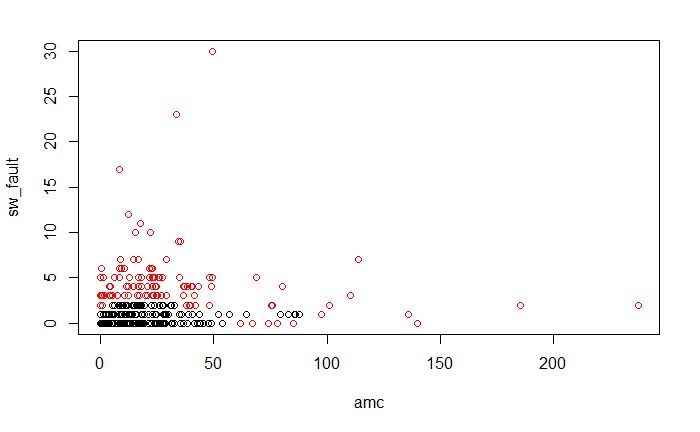

```r
plot(amc, sw_fault, col="red")
points(nonOutliersCook4l_amc, nonOutliersCook4l_sw_fault, col="black")
```

Even in this case, the scatterplot shows that a very huge number of data-points has been considered outliers and has been removed from the original data. This is a possible reason to support the choice to consider this model as not statistically-significant.

```r
cat("Data-points in the original data:",
    length(sw_fault))
```

```
Data-points in the original data: 340
```

```r
cat("Data-points removed from the original data:",
    length(sw_fault) - length(nonOutliersCook4l_sw_fault))
```

```
Data-points removed from the original data: 109
```

The model is finally re-created and the OLS assumptions are checked on the data with the outliers removed.

```r
nonOutliersCook4l_sw_faultsVSamc <- lm(nonOutliersCook4l_sw_fault~nonOutliersCook4l_amc)

nonOutliersCook4l_corrCoeff <- correlation.coefficients(nonOutliersCook4l_amc,
                                                        nonOutliersCook4l_sw_fault,
                                                        nonOutliersCook4l_sw_faultsVSamc)
```

```
    Pearson's product-moment correlation

data:  x and y
t = 1.3972, df = 229, p-value = 0.08185
alternative hypothesis: true correlation is greater than 0
95 percent confidence interval:
 -0.01673179  1.00000000
sample estimates:
       cor
0.09193937


    Spearman's rank correlation rho

data:  y and x
S = 1776961, p-value = 0.04031
alternative hypothesis: true rho is not equal to 0
sample estimates:
      rho
0.1350295


    Kendall's rank correlation tau

data:  y and x
z = 2.0406, p-value = 0.02065
alternative hypothesis: true tau is greater than 0
sample estimates:
      tau
0.1057326


    Shapiro-Wilk normality test

data:  ols_model$residuals
W = 0.78173, p-value < 2.2e-16
```

```r
colnames(nonOutliersCook4l_corrCoeff) <- c('NonOutCook4l_SwFaultVSAMC')
nonOutliersCook4l_corrCoeff
```

```
                     NonOutCook4l_SwFaultVSAMC
Pearson's R                       9.193937e-02
Spearman's Rho                    1.350295e-01
Kendall's Tau                     1.057326e-01
Shapiro-Wilk p-value              3.028734e-17
```

Comparing the obtained results with the ones obtained on the original data, the Pearson’s R coefficient is slightly increased, but both the Spearman’s rho, but the Kendall’s tau are slightly decreased. However, the p-value computed by the Shapiro-Wilk test is still less than 0.05. So, this transformation did not work in this situation.

It is also possible to graphically check the differences between the two OLS lines of regression.

```r
plot(amc, sw_fault)
abline(sw_faultVSamc)
```

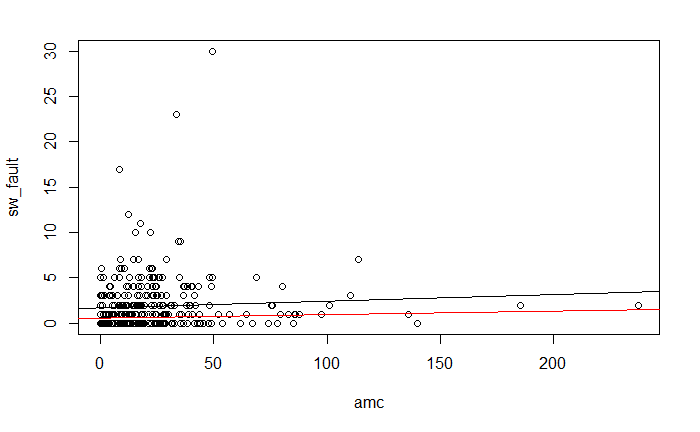

```r
abline(nonOutliersCook4l_sw_faultsVSamc, col="red")
```

### Final considerations

The application of the OLS technique on the variables AMC and Software Faultiness is not possible, because these two variables are not linearly dependent.

In particular, it is possible to report the main coefficient that evaluate the linear dependency of these two variables over the different analysis performed.

```r
cbind(orig_corrCoeff, log_corrCoeff, nonOutliersCook4l_corrCoeff)
```

```
                     SwFaultVSAMC Log_SwFaultVSAMC NonOutCook4l_SwFaultVSAMC
Pearson's R          6.695646e-02     1.826309e-01              9.193937e-02
Spearman's Rho       1.702467e-01     1.702467e-01              1.350295e-01
Kendall's Tau        1.251595e-01     1.251595e-01              1.057326e-01
Shapiro-Wilk p-value 8.840700e-27     2.491235e-11              3.028734e-17
```

Looking at the above table, it is possible to state that none of the data transformation techniques allow the data to be linearly dependent.

## Univariate statistically-significant model - OLS - Software Faultiness vs MOA

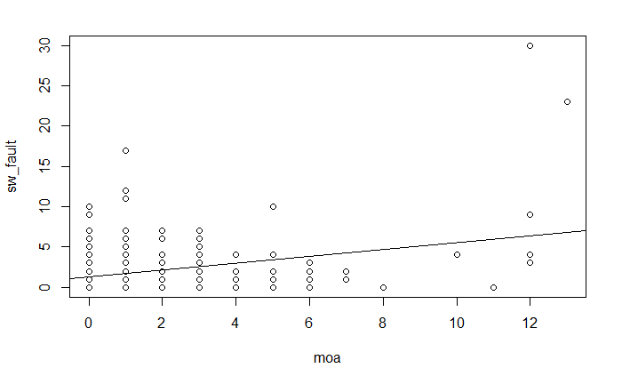

```r
sw_faultVSmoa <- lm(sw_fault~moa)

plot(moa, sw_fault)
abline(sw_faultVSmoa)
```

The steps performed to evaluate the results of the OLS technique applied to the variables Software Faultiness and MOA are the same performed in the previous analysis.

### Check of the assumptions

```r
orig_corrCoeff <- correlation.coefficients(moa, sw_fault, sw_faultVSmoa)
```

```
    Pearson's product-moment correlation

data:  x and y
t = 6.144, df = 338, p-value = 1.132e-09
alternative hypothesis: true correlation is greater than 0
95 percent confidence interval:
 0.234229 1.000000
sample estimates:
      cor
0.3169566


    Spearman's rank correlation rho

data:  y and x
S = 5689514, p-value = 0.01529
alternative hypothesis: true rho is not equal to 0
sample estimates:
      rho
0.1314528


    Kendall's rank correlation tau

data:  y and x
z = 2.418, p-value = 0.007803
alternative hypothesis: true tau is greater than 0
sample estimates:
      tau
0.1085797


    Shapiro-Wilk normality test

data:  ols_model$residuals
W = 0.74232, p-value < 2.2e-16
```

```r
colnames(orig_corrCoeff) <- c('SwFaultVSMOA')
orig_corrCoeff
```

```
                     SwFaultVSMOA
Pearson's R          3.169566e-01
Spearman's Rho       1.314528e-01
Kendall's Tau        1.085797e-01
Shapiro-Wilk p-value 1.224719e-22
```

According to the obtained results, the Pearson’s R coefficient shows a very slight degree of correlation, but both the Spearman’s rho and the Kendall’s tau are quite near to 0. The p-value computed by the Shapiro-Wilk test is less than 0.05.

### Data transformation - Logarithmic transformation

```r
log_sw_fault <- log(1+sw_fault)
log_moa <- log(1+moa)

log_sw_faultVSmoa <- lm(log_sw_fault~log_moa)
```

```r
log_corrCoeff <- correlation.coefficients(log_moa, log_sw_fault, log_sw_faultVSmoa)
```

```
    Pearson's product-moment correlation

data:  x and y
t = 3.1798, df = 338, p-value = 0.000805
alternative hypothesis: true correlation is greater than 0
95 percent confidence interval:
 0.08232034 1.00000000
sample estimates:
      cor
0.1704285


    Spearman's rank correlation rho

data:  y and x
S = 5689514, p-value = 0.01529
alternative hypothesis: true rho is not equal to 0
sample estimates:
      rho
0.1314528


    Kendall's rank correlation tau

data:  y and x
z = 2.418, p-value = 0.007803
alternative hypothesis: true tau is greater than 0
sample estimates:
      tau
0.1085797


    Shapiro-Wilk normality test

data:  ols_model$residuals
W = 0.92385, p-value = 3.892e-12
```

```r
colnames(log_corrCoeff) <- c('Log_SwFaultVSMOA')
log_corrCoeff
```

```
                     Log_SwFaultVSMOA
Pearson's R              1.704285e-01
Spearman's Rho           1.314528e-01
Kendall's Tau            1.085797e-01
Shapiro-Wilk p-value     3.891942e-12
```

According to the obtained results and with the results obtained on the original data, the results of both the Spearman’s rho and the Kendall’s tau are not changed, but the Pearson’s R is slightly decreased. Furthermore, the p-value computed by the Shapiro-Wilk test is still less than 0.05. So, this transformation did not work in this situation.

It is also possible to graphically check that the data are not linearly dependent.

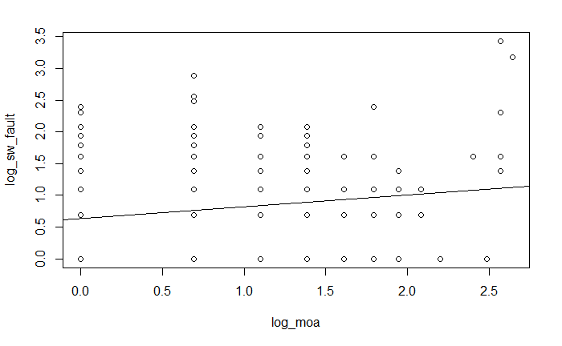

```r
plot(log_moa, log_sw_fault)
abline(log_sw_faultVSmoa)
```

### Data transformation - Outliers Removal

```r
cooksDistances <- cooks.distance(sw_faultVSmoa)
sum(cooksDistances > 4/length(cooksDistances))
```

```
[1] 19
```

```r
sum(cooksDistances > 1)
```

```
[1] 2
```

Since it is preferable to remove the fewest number of data-points, the case in which the threshold equals 1 is analyzed as first.

### Data transformation - Outliers Removal - Threshold = 1

In order to remove the outliers according to a threshold value equal to 1, the same function defined before is used.

```r
nonOutliersCook1 <- removeOutliersCook1(moa, sw_fault)
```

In order to make the code more clear, two new variables are created.

```r
nonOutliersCook1_moa <- nonOutliersCook1[[1]]
nonOutliersCook1_sw_fault <- nonOutliersCook1[[2]]
```

Before the correlation coefficient are computed on the new data, it is important to check how many data-points has been removed.

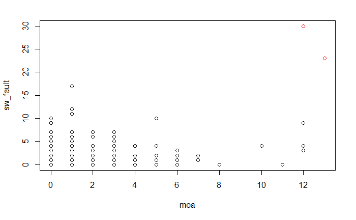

```r
plot(moa, sw_fault, col="red")
points(nonOutliersCook1_moa, nonOutliersCook1_sw_fault, col="black")
```

The model is finally re-created and the OLS assumptions are checked on the data with the outliers removed.

```r
nonOutliersCook1_sw_faultsVSmoa <- lm(nonOutliersCook1_sw_fault~nonOutliersCook1_moa)

nonOutliersCook1_corrCoeff <- correlation.coefficients(nonOutliersCook1_moa,
                                                        nonOutliersCook1_sw_fault,
                                                        nonOutliersCook1_sw_faultsVSmoa)
```

```
    Pearson's product-moment correlation

data:  x and y
t = 1.8222, df = 336, p-value = 0.03466
alternative hypothesis: true correlation is greater than 0
95 percent confidence interval:
 0.009375676 1.000000000
sample estimates:
       cor
0.09891935


    Spearman's rank correlation rho

data:  y and x
S = 5702251, p-value = 0.03624
alternative hypothesis: true rho is not equal to 0
sample estimates:
      rho
0.1139642


    Kendall's rank correlation tau

data:  y and x
z = 2.0793, p-value = 0.0188
alternative hypothesis: true tau is greater than 0
sample estimates:
       tau
0.09387212


    Shapiro-Wilk normality test

data:  ols_model$residuals
W = 0.77562, p-value < 2.2e-16
```

```r
colnames(nonOutliersCook1_corrCoeff) <- c('NonOutCook1_SwFaultVSMOA')
nonOutliersCook1_corrCoeff
```

```
                     NonOutCook1_SwFaultVSMOA
Pearson's R                      9.891935e-02
Spearman's Rho                   1.139642e-01
Kendall's Tau                    9.387212e-02
Shapiro-Wilk p-value             3.317458e-21
```

According to the obtained results and with the results obtained on the original data, all the results are worse. Furthermore, the p-value computed by the Shapiro-Wilk test is still less than 0.05. So, this transformation did not work in this situation.

It is also possible to graphically check the differences between the two OLS lines of regression.

```r
plot(moa, sw_fault)
abline(sw_faultVSmoa)
```

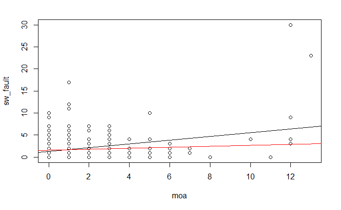

```r
abline(nonOutliersCook1_sw_faultsVSmoa, col="red")
```

### Data transformation - Outliers Removal - Threshold = 4/L

In order to remove the outliers according to a threshold value equal to 4/L, the same function defined before is used.

```r
nonOutliersCook4l <- removeOutliersCook4l(moa, sw_fault)
```

In order to make the code more clear, two new variables are created.

```r
nonOutliersCook4l_moa <- nonOutliersCook4l[[1]]
nonOutliersCook4l_sw_fault <- nonOutliersCook4l[[2]]
```

Before the correlation coefficient are computed on the new data, it is important to check how many data-points has been removed.

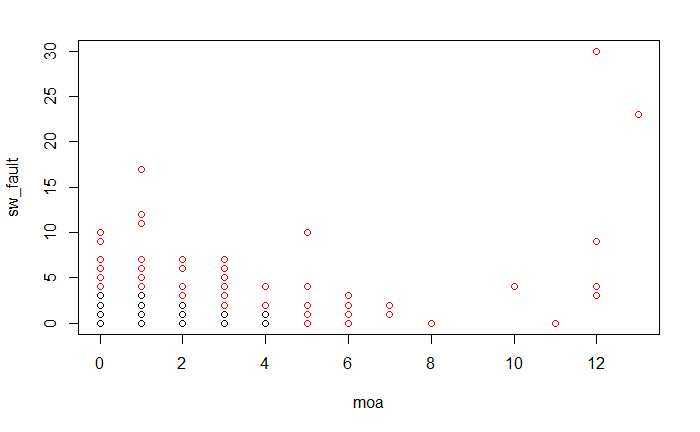

```r
plot(moa, sw_fault, col="red")
points(nonOutliersCook4l_moa, nonOutliersCook4l_sw_fault, col="black")
```

Even in this case, the scatterplot shows that a very huge number of data-points has been considered outliers and has been removed from the original data. This is a possible reason to support the choice to consider this model as not statistically-significant.

```r
cat("Data-points in the original data:",
    length(sw_fault))
```

```
Data-points in the original data: 340
```

```r
cat("Data-points removed from the original data:",
    length(sw_fault) - length(nonOutliersCook4l_sw_fault))
```

```
Data-points removed from the original data: 93
```

The model is finally re-created and the OLS assumptions are checked on the data with the outliers removed.

```r
nonOutliersCook4l_sw_faultsVSmoa <- lm(nonOutliersCook4l_sw_fault~nonOutliersCook4l_moa)

nonOutliersCook4l_corrCoeff <- correlation.coefficients(nonOutliersCook4l_moa,
                                                        nonOutliersCook4l_sw_fault,
                                                        nonOutliersCook4l_sw_faultsVSmoa)
```

```
    Pearson's product-moment correlation

data:  x and y
t = -1.4972, df = 245, p-value = 0.9322
alternative hypothesis: true correlation is greater than 0
95 percent confidence interval:
 -0.1981512  1.0000000
sample estimates:
        cor
-0.09521714


    Spearman's rank correlation rho

data:  y and x
S = 2620328, p-value = 0.4978
alternative hypothesis: true rho is not equal to 0
sample estimates:
        rho
-0.04333342


    Kendall's rank correlation tau

data:  y and x
z = -0.69154, p-value = 0.7554
alternative hypothesis: true tau is greater than 0
sample estimates:
        tau
-0.03933399


    Shapiro-Wilk normality test

data:  ols_model$residuals
W = 0.81169, p-value < 2.2e-16
```

```r
colnames(nonOutliersCook4l_corrCoeff) <- c('NonOutCook4l_SwFaultVSMOA')
nonOutliersCook4l_corrCoeff
```

```
                     NonOutCook4l_SwFaultVSMOA
Pearson's R                      -9.521714e-02
Spearman's Rho                   -4.333342e-02
Kendall's Tau                    -3.933399e-02
Shapiro-Wilk p-value              1.357935e-16
```

Comparing the obtained results with the ones obtained on the original data, all the results show worse results. In particular, all the values of the correlation coefficients have changed from low values quite near to 0 to negative values quite near to 0. The p-value computed by the Shapiro-Wilk test is still less than 0.05. So, this transformation did not work in this situation.

It is also possible to graphically check the differences between the two OLS lines of regression.

```r
plot(moa, sw_fault)
abline(sw_faultVSmoa)
```

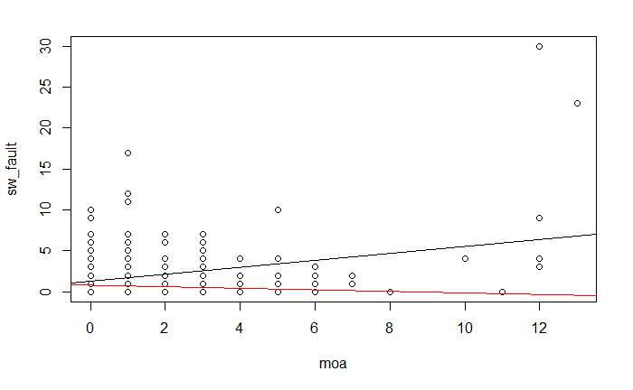

```r
abline(nonOutliersCook4l_sw_faultsVSmoa, col="red")
```

### Final considerations

The application of the OLS technique on the variables MOA and Software Faultiness is not possible, because these two variables are not linearly dependent.

In particular, it is possible to report the main coefficient that evaluate the linear dependency of these two variables over the different analysis performed.

```r
cbind(orig_corrCoeff, log_corrCoeff, nonOutliersCook1_corrCoeff, nonOutliersCook4l_corrCoeff)
```

```
                     SwFaultVSMOA Log_SwFaultVSMOA NonOutCook1_SwFaultVSMOA NonOutCook4l_SwFaultVSMOA
Pearson's R          3.169566e-01     1.704285e-01             9.891935e-02             -9.521714e-02
Spearman's Rho       1.314528e-01     1.314528e-01             1.139642e-01             -4.333342e-02
Kendall's Tau        1.085797e-01     1.085797e-01             9.387212e-02             -3.933399e-02
Shapiro-Wilk p-value 1.224719e-22     3.891942e-12             3.317458e-21              1.357935e-16
```

Looking at the above table, it is possible to state that only the original data show a very slight degree of correlation. In particular, all the data transformation techniques reduce the degree of linear dependency among the two variables.

## Univariate statistically-significant model - OLS - Software Faultiness vs LCOM

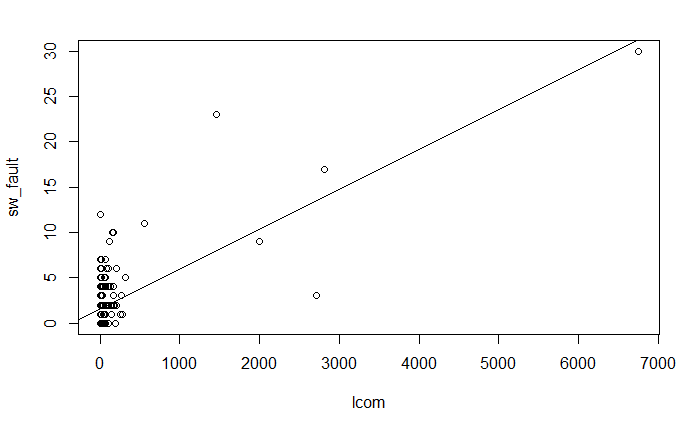

```r
sw_faultVSlcom <- lm(sw_fault~lcom)

plot(lcom, sw_fault)
abline(sw_faultVSlcom)
```

The steps performed to evaluate the results of the OLS technique applied to the variables Software Faultiness and LCOM are the same performed in the previous analysis.

### Check of the assumptions

```r
orig_corrCoeff <- correlation.coefficients(lcom, sw_fault, sw_faultVSlcom)
```

```
    Pearson's product-moment correlation

data:  x and y
t = 15.914, df = 338, p-value < 2.2e-16
alternative hypothesis: true correlation is greater than 0
95 percent confidence interval:
 0.600214 1.000000
sample estimates:
      cor
0.6544725


    Spearman's rank correlation rho

data:  y and x
S = 5325716, p-value = 0.0005286
alternative hypothesis: true rho is not equal to 0
sample estimates:
      rho
0.1869893


    Kendall's rank correlation tau

data:  y and x
z = 3.4799, p-value = 0.0002508
alternative hypothesis: true tau is greater than 0
sample estimates:
      tau
0.1462129


    Shapiro-Wilk normality test

data:  ols_model$residuals
W = 0.77572, p-value < 2.2e-16
```

```r
colnames(orig_corrCoeff) <- c('SwFaultVSLCOM')
orig_corrCoeff
```

```
                     SwFaultVSLCOM
Pearson's R           6.544725e-01
Spearman's Rho        1.869893e-01
Kendall's Tau         1.462129e-01
Shapiro-Wilk p-value  2.904956e-21
```

According to the obtained results, the Pearson’s R coefficient shows a slight degree of correlation, but both the Spearman’s rho and the Kendall’s tau are quite near to 0. The p-value computed by the Shapiro-Wilk test is less than 0.05.

### Data transformation - Logarithmic transformation

```r
log_sw_fault <- log(1+sw_fault)
log_lcom <- log(1+lcom)

log_sw_faultVSlcom <- lm(log_sw_fault~log_lcom)
```

```r
log_corrCoeff <- correlation.coefficients(log_lcom, log_sw_fault, log_sw_faultVSlcom)
```

```
    Pearson's product-moment correlation

data:  x and y
t = 6.067, df = 338, p-value = 1.747e-09
alternative hypothesis: true correlation is greater than 0
95 percent confidence interval:
 0.2304688 1.0000000
sample estimates:
      cor
0.3133767


    Spearman's rank correlation rho

data:  y and x
S = 5325716, p-value = 0.0005286
alternative hypothesis: true rho is not equal to 0
sample estimates:
      rho
0.1869893


    Kendall's rank correlation tau

data:  y and x
z = 3.4799, p-value = 0.0002508
alternative hypothesis: true tau is greater than 0
sample estimates:
      tau
0.1462129


    Shapiro-Wilk normality test

data:  ols_model$residuals
W = 0.94647, p-value = 9.256e-10
```

```r
colnames(log_corrCoeff) <- c('Log_SwFaultVSLCOM')
log_corrCoeff
```

```
                     Log_SwFaultVSLCOM
Pearson's R               3.133767e-01
Spearman's Rho            1.869893e-01
Kendall's Tau             1.462129e-01
Shapiro-Wilk p-value      9.256069e-10
```

According to the obtained results and with the results obtained on the original data, the results of both the Spearman’s rho and the Kendall’s tau are not changed, but the Pearson’s R is strongly decreased. Furthermore, the p-value computed by the Shapiro-Wilk test is still less than 0.05. So, this transformation did not work in this situation.

It is also possible to graphically check that the data are not linearly dependent.

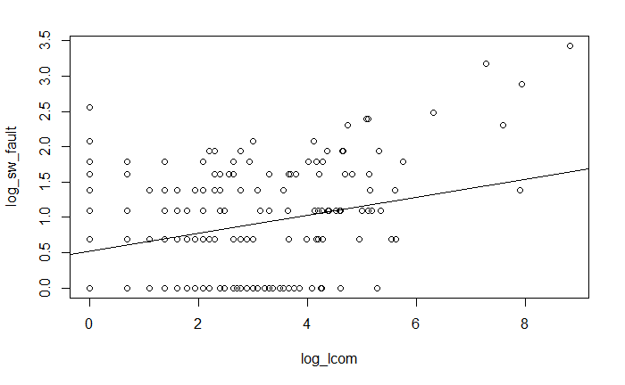

```r
plot(log_lcom, log_sw_fault)
abline(log_sw_faultVSlcom)
```

### Data transformation - Outliers Removal

```r
cooksDistances <- cooks.distance(sw_faultVSlcom)
sum(cooksDistances > 4/length(cooksDistances))
```

```
[1] 9
```

```r
sum(cooksDistances > 1)
```

```
[1] 1
```

Since it is preferable to remove the fewest number of data-points, the case in which the threshold equals 1 is analyzed as first.

### Data transformation - Outliers Removal - Threshold = 1

In order to remove the outliers according to a threshold value equal to 1, the same function defined before is used.

```r
nonOutliersCook1 <- removeOutliersCook1(lcom, sw_fault)
```

In order to make the code more clear, two new variables are created.

```r
nonOutliersCook1_lcom <- nonOutliersCook1[[1]]
nonOutliersCook1_sw_fault <- nonOutliersCook1[[2]]
```

Before the correlation coefficient are computed on the new data, it is important to check how many data-points has been removed.

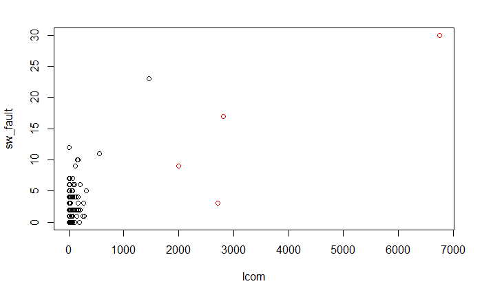

```r
plot(lcom, sw_fault, col="red")
points(nonOutliersCook1_lcom, nonOutliersCook1_sw_fault, col="black")
```

The model is finally re-created and the OLS assumptions are checked on the data with the outliers removed.

```r
nonOutliersCook1_sw_faultsVSlcom <- lm(nonOutliersCook1_sw_fault~nonOutliersCook1_lcom)

nonOutliersCook1_corrCoeff <- correlation.coefficients(nonOutliersCook1_lcom,
                                                        nonOutliersCook1_sw_fault,
                                                        nonOutliersCook1_sw_faultsVSlcom)
```

```
    Pearson's product-moment correlation

data:  x and y
t = 12.742, df = 334, p-value < 2.2e-16
alternative hypothesis: true correlation is greater than 0
95 percent confidence interval:
 0.5081443 1.0000000
sample estimates:
      cor
0.5719139


    Spearman's rank correlation rho

data:  y and x
S = 5314923, p-value = 0.00341
alternative hypothesis: true rho is not equal to 0
sample estimates:
      rho
0.1593132


    Kendall's rank correlation tau

data:  y and x
z = 2.9318, p-value = 0.001685
alternative hypothesis: true tau is greater than 0
sample estimates:
      tau
0.1242983


    Shapiro-Wilk normality test

data:  ols_model$residuals
W = 0.84712, p-value < 2.2e-16
```

```r
colnames(nonOutliersCook1_corrCoeff) <- c('NonOutCook1_SwFaultVSLCOM')
nonOutliersCook1_corrCoeff
```

```
                     NonOutCook1_SwFaultVSLCOM
Pearson's R                       5.719139e-01
Spearman's Rho                    1.593132e-01
Kendall's Tau                     1.242983e-01
Shapiro-Wilk p-value              1.351111e-17
```

According to the obtained results and with the results obtained on the original data, the Pearson’s R coefficient is slightly decreased, but still significant. However, both the Spearman’s rho and the Kendall’s tau are quite near to 0. Furthermore, the p-value computed by the Shapiro-Wilk test is still less than 0.05. So, this transformation did not work in this situation.

It is also possible to graphically check the differences between the two OLS lines of regression.

```r
plot(lcom, sw_fault)
abline(sw_faultVSlcom)
```

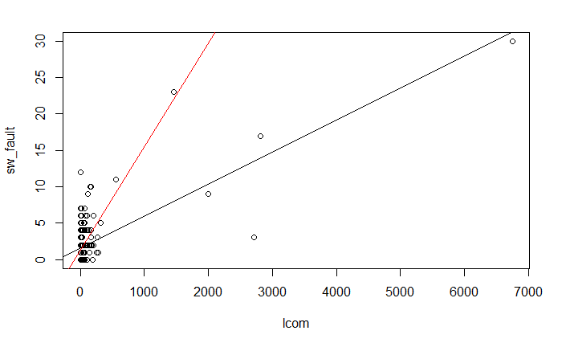

```r
abline(nonOutliersCook1_sw_faultsVSlcom, col="red")
```

### Data transformation - Outliers Removal - Threshold = 4/L

In order to remove the outliers according to a threshold value equal to 4/L, the same function defined before is used.

```r
nonOutliersCook4l <- removeOutliersCook4l(lcom, sw_fault)
```

In order to make the code more clear, two new variables are created.

```r
nonOutliersCook4l_lcom <- nonOutliersCook4l[[1]]
nonOutliersCook4l_sw_fault <- nonOutliersCook4l[[2]]
```

Before the correlation coefficient are computed on the new data, it is important to check how many data-points has been removed.

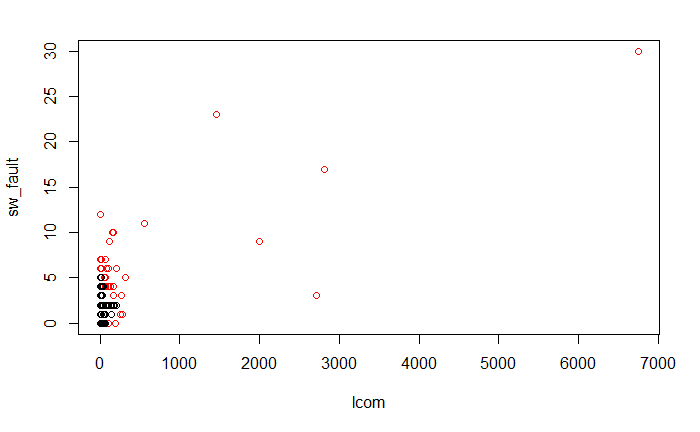

```r
plot(lcom, sw_fault, col="red")
points(nonOutliersCook4l_lcom, nonOutliersCook4l_sw_fault, col="black")
```

It can be usefut to print the number of data-points that have been removed from the function.

```r
cat("Data-points in the original data:",
    length(sw_fault))
```

```
Data-points in the original data: 340
```

```r
cat("Data-points removed from the original data:",
    length(sw_fault) - length(nonOutliersCook4l_sw_fault))
```

```
Data-points removed from the original data: 36
```

The model is finally re-created and the OLS assumptions are checked on the data with the outliers removed.

```r
nonOutliersCook4l_sw_faultsVSlcom <- lm(nonOutliersCook4l_sw_fault~nonOutliersCook4l_lcom)

nonOutliersCook4l_corrCoeff <- correlation.coefficients(nonOutliersCook4l_lcom,
                                                        nonOutliersCook4l_sw_fault,
                                                        nonOutliersCook4l_sw_faultsVSlcom)
```

```
    Pearson's product-moment correlation

data:  x and y
t = 1.1573, df = 302, p-value = 0.124
alternative hypothesis: true correlation is greater than 0
95 percent confidence interval:
 -0.02825576  1.00000000
sample estimates:
       cor
0.06644645


    Spearman's rank correlation rho

data:  y and x
S = 4554947, p-value = 0.6365
alternative hypothesis: true rho is not equal to 0
sample estimates:
       rho
0.02721129


    Kendall's rank correlation tau

data:  y and x
z = 0.48175, p-value = 0.315
alternative hypothesis: true tau is greater than 0
sample estimates:
       tau
0.02194179


    Shapiro-Wilk normality test

data:  ols_model$residuals
W = 0.80526, p-value < 2.2e-16
```

```r
colnames(nonOutliersCook4l_corrCoeff) <- c('NonOutCook4l_SwFaultVSLCOM')
nonOutliersCook4l_corrCoeff
```

```
                     NonOutCook4l_SwFaultVSLCOM
Pearson's R                        6.644645e-02
Spearman's Rho                     2.721129e-02
Kendall's Tau                      2.194179e-02
Shapiro-Wilk p-value               8.315815e-19
```

Comparing the obtained results with the ones obtained on the original data, all the results show worse results. In particular, all the values of the correlation coefficients are very near to 0. The p-value computed by the Shapiro-Wilk test is still less than 0.05. So, this transformation did not work in this situation.

It is also possible to graphically check the differences between the two OLS lines of regression.

```r
plot(lcom, sw_fault)
abline(sw_faultVSlcom)
```

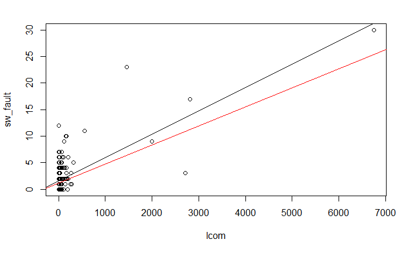

```r
abline(nonOutliersCook4l_sw_faultsVSlcom, col="red")
```

### Final considerations

The application of the OLS technique on the variables LCOM and Software Faultiness is not possible, because these two variables are not linearly dependent.

In particular, it is possible to report the main coefficient that evaluate the linear dependency of these two variables over the different analysis performed.

```r
cbind(orig_corrCoeff, log_corrCoeff, nonOutliersCook1_corrCoeff, nonOutliersCook4l_corrCoeff)
```

```
                     SwFaultVSLCOM Log_SwFaultVSLCOM NonOutCook1_SwFaultVSLCOM NonOutCook4l_SwFaultVSLCOM
Pearson's R           6.544725e-01      3.133767e-01              5.719139e-01               6.644645e-02
Spearman's Rho        1.869893e-01      1.869893e-01              1.593132e-01               2.721129e-02
Kendall's Tau         1.462129e-01      1.462129e-01              1.242983e-01               2.194179e-02
Shapiro-Wilk p-value  2.904956e-21      9.256069e-10              1.351111e-17               8.315815e-19
```

Looking at the above table, it is possible to state that both the original data and the ones where the outliers are removed according to a threshold value equal to 1 show a slight degree of correlation. However, in both these cases, both the Spearman’s rho and the Kendall’s tau are quite near to 0 and the p-value computed by the Shapiro-Wilk test is always less than 0.05.

## Univariate statistically-significant model - OLS - Results evaluation

Looking at the results obtained through the application of the OLS technique to all the pairs of independent-dependent variables, it is possible to state that a statistically-significant model is never built-up using OLS.

# Univariate statistically-significant model - Binary Logistic Regression

The Binary Logistic Regression is a statistical technique used to predict the relationship between one or more independent variables and a the dependent one, where the dependent variable can only assume two possible values.

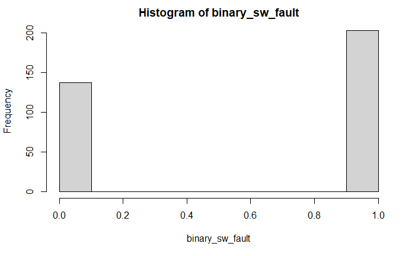

```r
binary_sw_fault <- ifelse(sw_fault > 0, 1, 0)
hist(binary_sw_fault)
```

In particular, the dependent variable is transformed in such a way that it can only assume the values 1 when the data-point is considered as a faulty artifact or 0 when the data-point is considered as a non-faulty artifact.

## Univariate statistically-significant model - Binary Logistic Regression - Software Faultiness vs LOC

It can be useful to plot how both the faulty and non-faulty data-points are distributed with respect to the LOC variable.

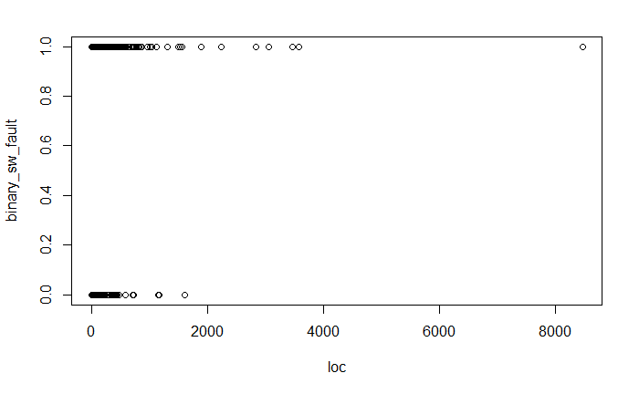

```r
plot(loc, binary_sw_fault)
```

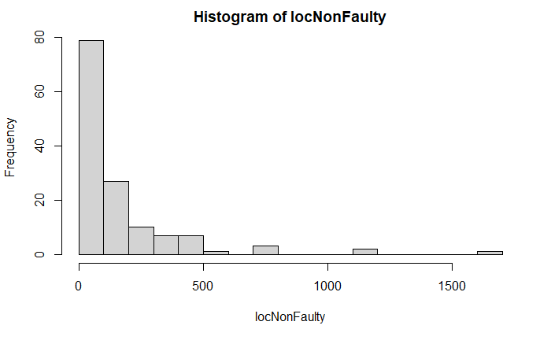

```r
locNonFaulty <- loc[binary_sw_fault %in% 0]
hist(locNonFaulty, breaks = 20)
```

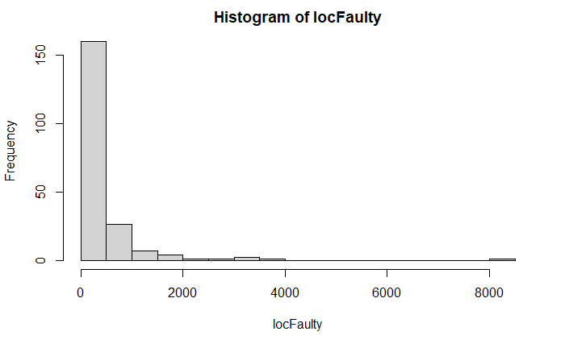

```r
locFaulty <- loc[binary_sw_fault %in% 1]
hist(locFaulty, breaks = 20)
```

Then, the model is built-up.

```r
binary_sw_faultVSloc <- glm( binary_sw_fault~loc, family=binomial(link="logit"))
summary(binary_sw_faultVSloc)
```

```
Call:
glm(formula = binary_sw_fault ~ loc, family = binomial(link = "logit"))

Deviance Residuals:
    Min       1Q   Median       3Q      Max
-2.4709  -1.1908   0.7597   1.0972   1.1925

Coefficients:
              Estimate Std. Error z value Pr(>|z|)
(Intercept) -0.0372196  0.1469234  -0.253  0.80002
loc          0.0018950  0.0004999   3.791  0.00015 ***
---
Signif. codes:  0 ‘***’ 0.001 ‘**’ 0.01 ‘*’ 0.05 ‘.’ 0.1 ‘ ’ 1

(Dispersion parameter for binomial family taken to be 1)

    Null deviance: 458.45  on 339  degrees of freedom
Residual deviance: 434.08  on 338  degrees of freedom
AIC: 438.08

Number of Fisher Scoring iterations: 5
```

### Binary Logistic Regression - Software Faultiness vs LOC - Fault-proneness model

After the Binary Logistic Regression model is built-up, it can be used as a fault-proneness model in order to estimate the probability of an artifact to be faulty.

In particular, the first step involves the graphical plot of the model.

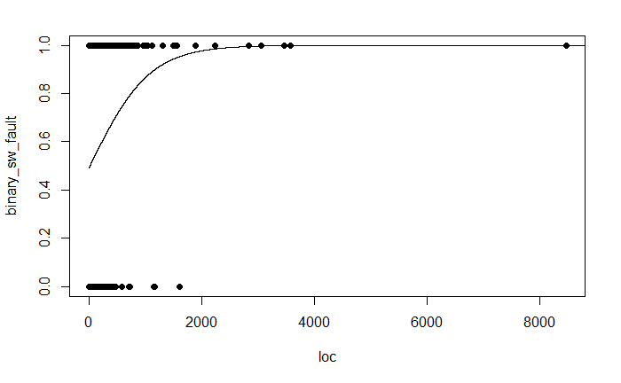

```r
xweight <- seq(min(loc), max(loc)*1.1, 0.1)
yweight <- predict(binary_sw_faultVSloc, list(loc = xweight), type="response")
plot(loc, binary_sw_fault, pch = 16, xlab = "loc", ylab = "binary_sw_fault")
lines(xweight, yweight)
```

It is also needed the definition of thresholds in addition to fault-proneness model. In particular, concerning the Software Faultiness variable, the threshold is set to the proportion of faulty data-points. Concerning the LOC variable, the threshold is set to the difference between the log odds of an artifact to be faulty according to the faulty proportion and the log odds of an artifact to be faulty according to the LOC variable.

```r
# In order to plot the threshold values, it is needed to re-create the scatterplot
plot(loc, binary_sw_fault, pch = 16, xlab = "loc", ylab = "binary_sw_fault")
lines(xweight, yweight)
```

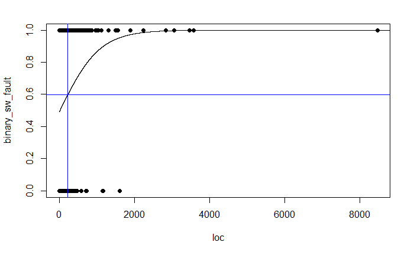

```r
# Computation and plot of the threshold values
faultyProportion <- sum(binary_sw_fault)/length(binary_sw_fault)
abline(h=faultyProportion, col="blue")

x <- (log(faultyProportion/(1-faultyProportion))-
        coef(binary_sw_faultVSloc)[1])/coef(binary_sw_faultVSloc)[2]
abline(v = x, col="blue")
```

In order to evaluate the performances of the classifier, it is needed to compute the contingency table.

```r
estimatedFaulty <- binary_sw_faultVSloc$fitted.values > faultyProportion
actualFaulty <- binary_sw_fault == 1
contingencyTable <- table(estimatedFaulty, actualFaulty)
contingencyTable
```

```
               actualFaulty
estimatedFaulty FALSE TRUE
          FALSE   107  118
          TRUE     30   85
```

Given the contingency table, it is possible to compute the accuracy, precision and recall. In particular,

- The accuracy represents the proportion of correct classifications, and it is computed as ratio between the number of correct predictions and the number of samples.
- The precision represents the proportion of estimated positives that are actually positive, and it is computed as the ratio between the number of true positives and the number of estimated positives.
- The recall represents the proportion of actual positives that are also estimated as positives, and it is computed as the ratio between the number of true positives and the number of actual positives.

In particular, it can be useful to define a function that computes these coefficients according to the contingency table.

```r
accurIndNames <- c('Accuracy', 'Precision', 'Recall')

accuracy.indicators <- function(contingencyTable) {
  accuracy <- (contingencyTable[1,1]+contingencyTable[2,2])/sum(contingencyTable)
  precision <- contingencyTable[2,2]/sum(contingencyTable[2,])
  recall <- contingencyTable[2,2]/sum(contingencyTable[,2])
  matrix <- matrix(c(accuracy, precision, recall), byrow=TRUE)
  rownames(matrix) <- accurIndNames
  return (as.table(matrix))
}
```

Then, the function is called to compute the accuracy indicators of the model.

```r
accurInd <- accuracy.indicators(contingencyTable)
colnames(accurInd) <- c('SwFaultVSLOC')
round(accurInd,2)
```

```
          SwFaultVSLOC
Accuracy          0.56
Precision         0.74
Recall            0.42
```

According to the obtained results, the model does not show very good values of accuracy. In particular, the recall value equals 0.42 and the accuracy value equals 0.56. However, the model shows a very good value of precision, meaning that it is quite able to recognize faulty artifacts. Furthermore, since the model works using just an independent variable as predictor, these result can be considered as acceptable ones.

## Univariate statistically-significant model - Binary Logistic Regression - Software Faultiness vs AMC

It can be useful to plot how both the faulty and non-faulty data-points are distributed with respect to the AMC variable.

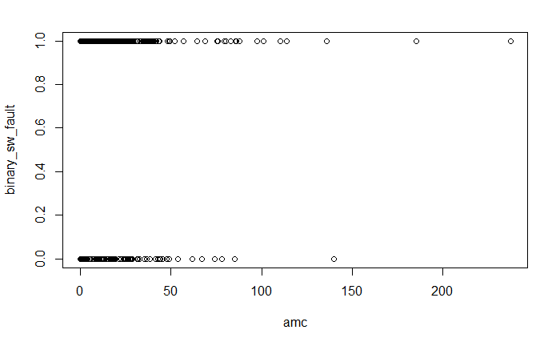

```r
plot(amc, binary_sw_fault)
```

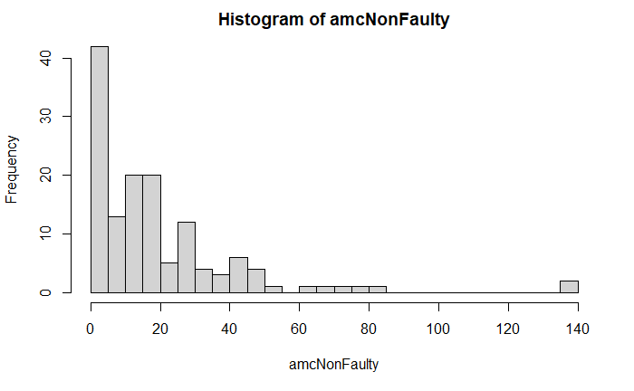

```r
amcNonFaulty <- amc[binary_sw_fault %in% 0]
hist(amcNonFaulty, breaks = 20)
```

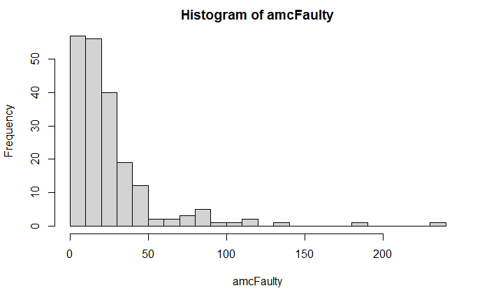

```r
amcFaulty <- amc[binary_sw_fault %in% 1]
hist(amcFaulty, breaks = 20)
```

Then, the model is built-up.

```r
binary_sw_faultVSamc <- glm( binary_sw_fault~amc, family=binomial(link="logit"))
summary(binary_sw_faultVSamc)
```

```
Call:
glm(formula = binary_sw_fault ~ amc, family = binomial(link = "logit"))

Deviance Residuals:
    Min       1Q   Median       3Q      Max
-1.9182  -1.2871   0.9438   1.0428   1.1117

Coefficients:
            Estimate Std. Error z value Pr(>|z|)
(Intercept) 0.156625   0.152703   1.026   0.3050
amc         0.010787   0.005045   2.138   0.0325 *
---
Signif. codes:  0 ‘***’ 0.001 ‘**’ 0.01 ‘*’ 0.05 ‘.’ 0.1 ‘ ’ 1

(Dispersion parameter for binomial family taken to be 1)

    Null deviance: 458.45  on 339  degrees of freedom
Residual deviance: 453.03  on 338  degrees of freedom
AIC: 457.03

Number of Fisher Scoring iterations: 4
```

### Binary Logistic Regression - Software Faultiness vs AMC - Fault-proneness model

After the Binary Logistic Regression model is built-up, it can be used as a fault-proneness model in order to estimate the probability of an artifact to be faulty.

In particular, the first step involves the graphical plot of the model.

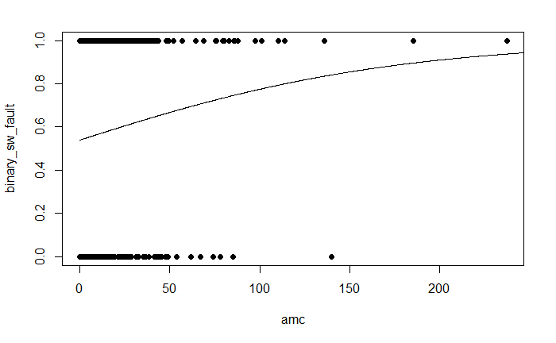

```r
xweight <- seq(min(amc), max(amc)*1.1, 0.1)
yweight <- predict(binary_sw_faultVSamc, list(amc = xweight), type="response")
plot(amc, binary_sw_fault, pch = 16, xlab = "amc", ylab = "binary_sw_fault")
lines(xweight, yweight)
```

Then, the threshold values need to be computed.

```r
# In order to plot the threshold values, it is needed to re-create the scatterplot
plot(amc, binary_sw_fault, pch = 16, xlab = "amc", ylab = "binary_sw_fault")
lines(xweight, yweight)
```

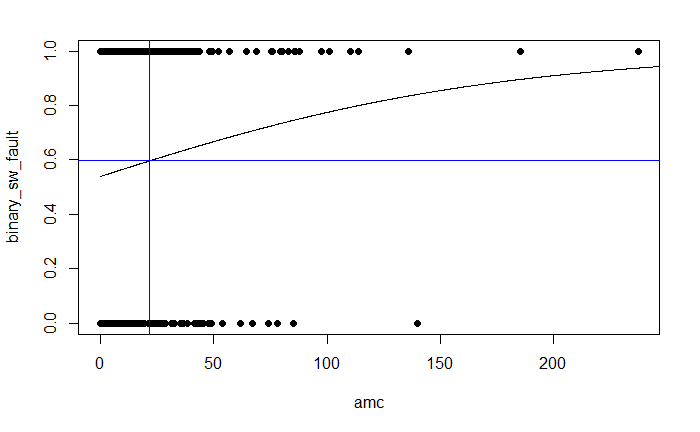

```r
# Computation and plot of the threshold values
faultyProportion <- sum(binary_sw_fault)/length(binary_sw_fault)
abline(h=faultyProportion, col="blue")

x <- (log(faultyProportion/(1-faultyProportion))-
        coef(binary_sw_faultVSamc)[1])/coef(binary_sw_faultVSamc)[2]
abline(v = x, col="blue")
```

In order to evaluate the performances of the classifier, it is needed to compute the contingency table.

```r
estimatedFaulty <- binary_sw_faultVSamc$fitted.values > faultyProportion
actualFaulty <- binary_sw_fault == 1
contingencyTable <- table(estimatedFaulty, actualFaulty)
contingencyTable
```

```
               actualFaulty
estimatedFaulty FALSE TRUE
          FALSE    96  119
          TRUE     41   84
```

Finally, the previously-defined function is called to compute the accuracy indicators of the model.

```r
accurInd <- accuracy.indicators(contingencyTable)
colnames(accurInd) <- c('SwFaultVSAMC')
round(accurInd, 2)
```

```
          SwFaultVSAMC
Accuracy          0.53
Precision         0.67
Recall            0.41
```

According to the obtained results, the model shows the accuracy values to be slightly worse than the ones obtained using the LOC variable as predictor. However, even in this case the results can be considered as quite good ones.

## Univariate statistically-significant model - Binary Logistic Regression - Software Faultiness vs MOA

It can be useful to plot how both the faulty and non-faulty data-points are distributed with respect to the MOA variable.

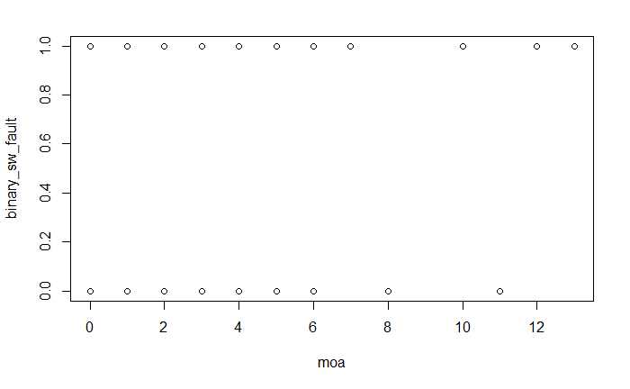

```r
plot(moa, binary_sw_fault)
```

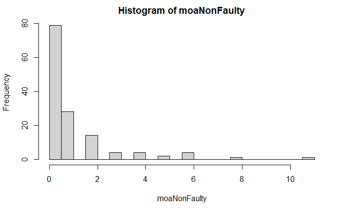

```r
moaNonFaulty <- moa[binary_sw_fault %in% 0]
hist(moaNonFaulty, breaks = 20)
```

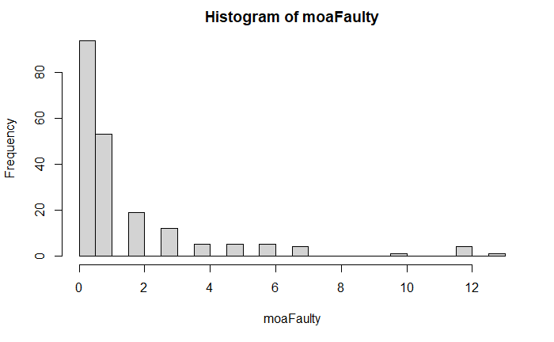

```r
moaFaulty <- moa[binary_sw_fault %in% 1]
hist(moaFaulty, breaks = 20)
```

Then, the model is built-up.

```r
binary_sw_faultVSmoa <- glm( binary_sw_fault~moa, family=binomial(link="logit"))
summary(binary_sw_faultVSmoa)
```

```
Call:
glm(formula = binary_sw_fault ~ moa, family = binomial(link = "logit"))

Deviance Residuals:
    Min       1Q   Median       3Q      Max
-1.8343  -1.2891   0.9389   1.0697   1.0697

Coefficients:
            Estimate Std. Error z value Pr(>|z|)
(Intercept)  0.25871    0.12870   2.010   0.0444 *
moa          0.11072    0.05741   1.929   0.0538 .
---
Signif. codes:  0 ‘***’ 0.001 ‘**’ 0.01 ‘*’ 0.05 ‘.’ 0.1 ‘ ’ 1

(Dispersion parameter for binomial family taken to be 1)

    Null deviance: 458.45  on 339  degrees of freedom
Residual deviance: 454.28  on 338  degrees of freedom
AIC: 458.28

Number of Fisher Scoring iterations: 4
```

### Binary Logistic Regression - Software Faultiness vs MOA - Fault-proneness model

After the Binary Logistic Regression model is built-up, it can be used as a fault-proneness model in order to estimate the probability of an artifact to be faulty.

In particular, the first step involves the graphical plot of the model.

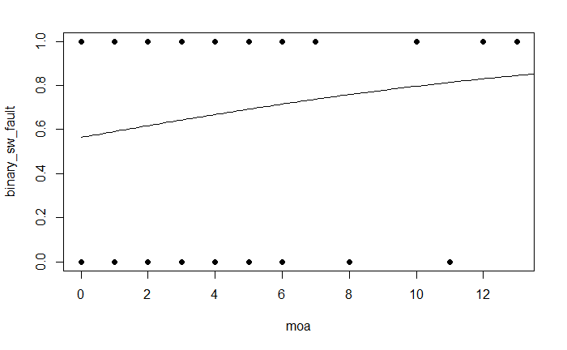

```r
xweight <- seq(min(moa), max(moa)*1.1, 0.1)
yweight <- predict(binary_sw_faultVSmoa, list(moa = xweight), type="response")
plot(moa, binary_sw_fault, pch = 16, xlab = "moa", ylab = "binary_sw_fault")
lines(xweight, yweight)
```

Then, the threshold values need to be computed.

```r
# In order to plot the threshold values, it is needed to re-create the scatterplot
plot(moa, binary_sw_fault, pch = 16, xlab = "moa", ylab = "binary_sw_fault")
lines(xweight, yweight)
```

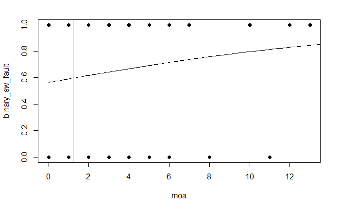

```r
# Computation and plot of the threshold values
faultyProportion <- sum(binary_sw_fault)/length(binary_sw_fault)
abline(h=faultyProportion, col="blue")

x <- (log(faultyProportion/(1-faultyProportion))-
        coef(binary_sw_faultVSmoa)[1])/coef(binary_sw_faultVSmoa)[2]
abline(v = x, col="blue")
```

In order to evaluate the performances of the classifier, it is needed to compute the contingency table.

```r
estimatedFaulty <- binary_sw_faultVSmoa$fitted.values > faultyProportion
actualFaulty <- binary_sw_fault == 1
contingencyTable <- table(estimatedFaulty, actualFaulty)
contingencyTable
```

```
               actualFaulty
estimatedFaulty FALSE TRUE
          FALSE   107  147
          TRUE     30   56
```

Finally, the previously-defined function is called to compute the accuracy indicators of the model.

```r
accurInd <- accuracy.indicators(contingencyTable)
colnames(accurInd) <- c('SwFaultVSMOA')
round(accurInd, 2)
```

```
          SwFaultVSMOA
Accuracy          0.48
Precision         0.65
Recall            0.28
```

According to the obtained results, the model shows the accuracy values to be slightly worse than the ones obtained in the previous analysis. In particular, these results cannot be considered as good ones.

## Univariate statistically-significant model - Binary Logistic Regression - Software Faultiness vs LCOM

It can be useful to plot how both the faulty and non-faulty data-points are distributed with respect to the LCOM variable.

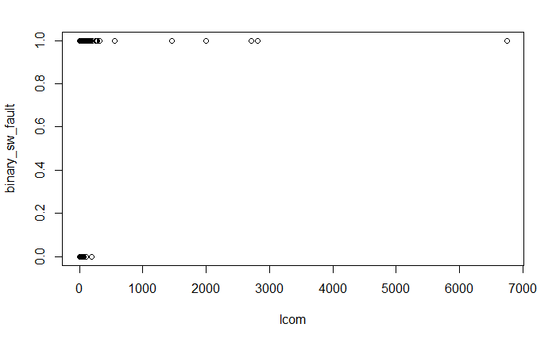

```r
plot(lcom, binary_sw_fault)
```

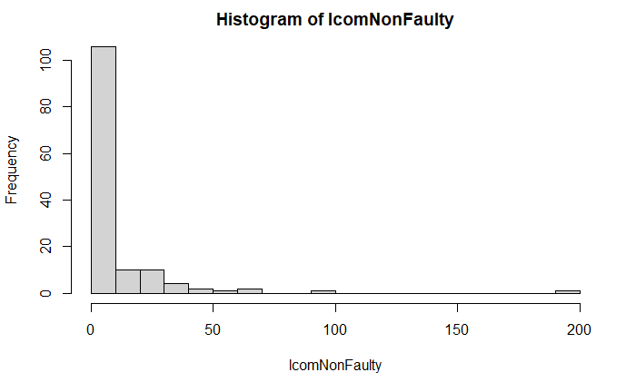

```r
lcomNonFaulty <- lcom[binary_sw_fault %in% 0]
hist(lcomNonFaulty, breaks = 20)
```

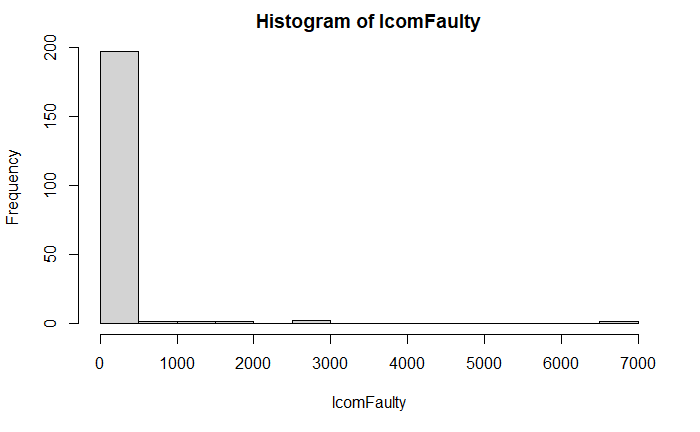

```r
lcomFaulty <- lcom[binary_sw_fault %in% 1]
hist(lcomFaulty, breaks = 20)
```

Then, the model is built-up.

```r
binary_sw_faultVSlcom <- glm( binary_sw_fault~lcom, family=binomial(link="logit"))
```

```
glm.fit: fitted probabilities numerically 0 or 1 occurred
```

```r
summary(binary_sw_faultVSlcom)
```

```
Call:
glm(formula = binary_sw_fault ~ lcom, family = binomial(link = "logit"))

Deviance Residuals:
   Min      1Q  Median      3Q     Max
-2.437  -1.239   0.727   1.111   1.123

Coefficients:
            Estimate Std. Error z value Pr(>|z|)
(Intercept) 0.128740   0.125131   1.029 0.303555
lcom        0.014231   0.004288   3.319 0.000905 ***
---
Signif. codes:  0 ‘***’ 0.001 ‘**’ 0.01 ‘*’ 0.05 ‘.’ 0.1 ‘ ’ 1

(Dispersion parameter for binomial family taken to be 1)

    Null deviance: 458.45  on 339  degrees of freedom
Residual deviance: 434.26  on 338  degrees of freedom
AIC: 438.26

Number of Fisher Scoring iterations: 8
```

### Binary Logistic Regression - Software Faultiness vs LCOM - Fault-proneness model

After the Binary Logistic Regression model is built-up, it can be used as a fault-proneness model in order to estimate the probability of an artifact to be faulty.

In particular, the first step involves the graphical plot of the model.

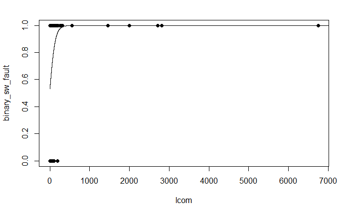

```r
xweight <- seq(min(lcom), max(lcom)*1.1, 0.1)
yweight <- predict(binary_sw_faultVSlcom, list(lcom = xweight), type="response")
plot(lcom, binary_sw_fault, pch = 16, xlab = "lcom", ylab = "binary_sw_fault")
lines(xweight, yweight)
```

Then, the threshold values need to be computed.

```r
# In order to plot the threshold values, it is needed to re-create the scatterplot
plot(lcom, binary_sw_fault, pch = 16, xlab = "lcom", ylab = "binary_sw_fault")
lines(xweight, yweight)
```

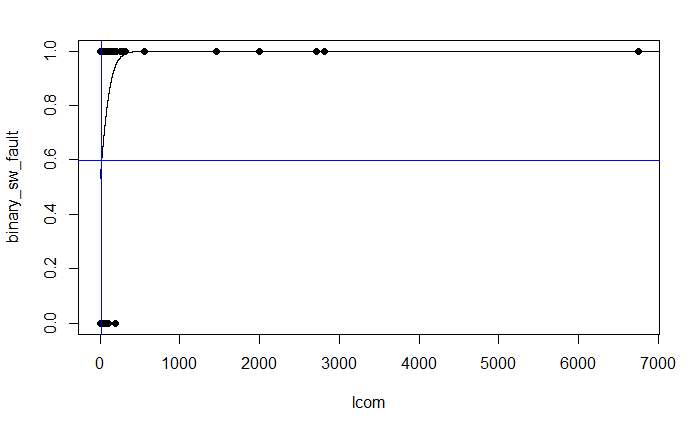

```r
# Computation and plot of the threshold values
faultyProportion <- sum(binary_sw_fault)/length(binary_sw_fault)
abline(h=faultyProportion, col="blue")

x <- (log(faultyProportion/(1-faultyProportion))-
        coef(binary_sw_faultVSlcom)[1])/coef(binary_sw_faultVSlcom)[2]
abline(v = x, col="blue")
```

In order to evaluate the performances of the classifier, it is needed to compute the contingency table.

```r
estimatedFaulty <- binary_sw_faultVSlcom$fitted.values > faultyProportion
actualFaulty <- binary_sw_fault == 1
contingencyTable <- table(estimatedFaulty, actualFaulty)
contingencyTable
```

```
               actualFaulty
estimatedFaulty FALSE TRUE
          FALSE   115  145
          TRUE     22   58
```

Finally, the previously-defined function is called to compute the accuracy indicators of the model.

```r
accurInd <- accuracy.indicators(contingencyTable)
colnames(accurInd) <- c('SwFaultVSLCOM')
round(accurInd, 2)
```

```
          SwFaultVSLCOM
Accuracy           0.51
Precision          0.72
Recall             0.29
```

According to the obtained results, the model shows the accuracy values to be slightly worse than the ones obtained using the LOC variable or the AMC variable as predictors. However, even in this case the results can be considered as quite good ones.

## Univariate statistically-significant model - Binary Logistic Regression - Results evaluation

Looking at the results obtained through the application of the Binary Logistic Regression with a single predictor, the variable that allows to obtain the best accuracy result is the LOC. In particular, in this case the model reaches an accuracy of 56% and a precision of 74%. Since only one variable is used to predict the label of the new data, this result can be considered as a good one. It is also possible to notice that even the independent variables AMC and LCOM allow to obtain a model with acceptable performances.

# Multivariate statistically-significant model - Naive Bayes Classifier

Naive Bayes is a Supervised Machine Learning algorithm based on the Bayes Theorem, and it is used to solve classification problems by following a probabilistic approach. It is based on the idea that the independent variables in a Machine Learning model are independent of each other. Meaning that the outcome of a model depends on a set of independent variables that have nothing to do with each other.

In order to build up a Naive Bayes Classifier, a dataframe structure is required.

```r
cleanedLucene <- lucene[c("bug","loc","amc","moa","lcom")]
```

Furthermore, it is needed to transform the dependent variable into a categorical one. In particular, the Software Faultiness’s values will be ‘Faulty’ or ‘Non-Faulty’ based on its original value.

```r
bug <- lucene$bug
binary_bug <- ifelse(bug > 0, 'Faulty', 'Non-Faulty')
cleanedLucene[["bug"]] <- binary_bug
head(cleanedLucene)
```

|  | bug | loc | amc | moa | lcom |
| --- | --- | --- | --- | --- | --- |
| 1 | Faulty | 84 | 14.40 | 7 | 0 |
| 2 | Faulty | 286 | 27.20 | 0 | 7 |
| 3 | Non-Faulty | 287 | 27.50 | 0 | 0 |
| 4 | Non-Faulty | 26 | 5.50 | 0 | 6 |
| 5 | Faulty | 596 | 22.36 | 5 | 160 |
| 6 | Non-Faulty | 8 | 0.60 | 0 | 10 |

### Check of the assumptions

The Naive Bayes Classifiers requires the independent variables to be independent with each other. In order to evaluate the degree of correlation among all the independent variables, the correlation matrix is computed.

```r
indep_var <- cleanedLucene[,-1]
corr_matr <- cor(indep_var)
round(corr_matr, 2)
```

```
      loc  amc  moa lcom
loc  1.00 0.48 0.49 0.78
amc  0.48 1.00 0.20 0.06
moa  0.49 0.20 1.00 0.42
lcom 0.78 0.06 0.42 1.00
```

Looking at the correlation matrix, the only pairs of variables that do not share a considerable degree of correlation are AMC-LCOM and AMC-MOA. So, these pairs of variables are the ones that will be analyzed as first.

## Naive Bayes Classifier - Software Faultiness vs AMC and LCOM

For sake of reproducibility, it is needed to set the value of the seed of the random number generator.

```r
set.seed(123456)
```

Furthermore, it is needed to import some useful libraries. The first one contains functions to streamline the model training process for complex regression and classification problems. The second one contains the functions used to create several well-known classification models.

```r
library(caret)
library(e1071)
```

The following step involves the creation of both the training and the test sets.

```r
trainIndex <- createDataPartition(cleanedLucene$bug, p=0.7)$Resample1
training <- cleanedLucene[trainIndex, ]
testing <- cleanedLucene[-trainIndex, ]
```

It is also possible to show some interesting characteristics of these two sets of data-points.

```r
cat("Number of data-points in the training set:", length(training$bug))
```

```
Number of data-points in the training set: 239
```

```r
cat("Number of data-points in the test set:", length(testing$bug))
```

```
Number of data-points in the test set: 101
```

```r
cat("Number of Faulty and Non-Faulty data-points in the training set:",
    table(training$bug))
```

```
Number of Faulty and Non-Faulty data-points in the training set: 143 96
```

```r
cat("Number of Faulty and Non-Faulty data-points in the test set:",
    table(testing$bug))
```

```
Number of Faulty and Non-Faulty data-points in the test set: 60 41
```

```r
cat("Proportion of Faulty and Non-Faulty data-points in the training set:",
    prop.table(table(training$bug)) * 100)
```

```
Proportion of Faulty and Non-Faulty data-points in the training set: 59.83264 40.16736
```

```r
cat("Proportion of Faulty and Non-Faulty data-points in the test set:",
    prop.table(table(testing$bug)) * 100)
```

```
Proportion of Faulty and Non-Faulty data-points in the test set: 59.40594 40.59406
```

Before the model is built-up, it is needed to create the two variables that will be passed to the model. In particular, the variable ‘x’ represents the set of independent variables that will be used by the model to compute the predicted values, and the variable ‘y’ represents the actual values.

```r
x <- training[,c("amc","lcom")]
head(x)
```

|  | amc | lcom |
| --- | --- | --- |
| 1 | 14.40 | 0 |
| 2 | 27.20 | 7 |
| 3 | 27.50 | 0 |
| 4 | 5.50 | 6 |
| 5 | 22.36 | 160 |
| 6 | 0.60 | 10 |

```r
y <- training$bug
head(y)
```

```
[1] "Faulty"     "Faulty"     "Non-Faulty" "Non-Faulty" "Faulty"     "Non-Faulty"
```

Once the two variables have been created, the model can be built-up. In particular, the ‘trControl’ parameter is used to control the printing and resampling for the training phase. In particular, the resampling is performed through the K-fold Cross-Validation technique, that is a resampling procedure used to evaluate machine learning models on a limited data sample. The procedure has a single parameter called k that specifies the number of groups in which the samples must be splitted into.

```r
model <- train(x,y,'nb',trControl=trainControl(method='cv',number=10))
```

```
Numerical 0 probability for all classes with observation 9Numerical 0 probability for all classes with observation 18Numerical 0 probability for all classes with observation 12Numerical 0 probability for all classes with observation 21
```

```r
model
```

```
Naive Bayes

239 samples
  2 predictor
  2 classes: 'Faulty', 'Non-Faulty'

No pre-processing
Resampling: Cross-Validated (10 fold)
Summary of sample sizes: 216, 216, 215, 215, 216, 214, ...
Resampling results across tuning parameters:

  usekernel  Accuracy   Kappa
  FALSE      0.4809855  0.09496045
   TRUE      0.5395290  0.03904404

Tuning parameter 'fL' was held constant at a value of 0
Tuning parameter 'adjust' was held constant at a
 value of 1
Accuracy was used to select the optimal model using the largest value.
The final values used for the model were fL = 0, usekernel = TRUE and adjust = 1.
```

Finally, the model is evaluated using the confusion matrix. In particular, the model is asked to predict the values contained in the test set, and then the predicted values are compared with the actual values.

```r
predictions <- predict(model,newdata = testing )
```

```
Numerical 0 probability for all classes with observation 46
```

```r
cm <- table(testing$bug, predictions)
confusionMatrix(cm)
```

```
Confusion Matrix and Statistics

            predictions
             Faulty Non-Faulty
  Faulty         52          8
  Non-Faulty     30         11

               Accuracy : 0.6238
                 95% CI : (0.5218, 0.7182)
    No Information Rate : 0.8119
    P-Value [Acc > NIR] : 0.9999972

                  Kappa : 0.1475

 Mcnemar's Test P-Value : 0.0006577

            Sensitivity : 0.6341
            Specificity : 0.5789
         Pos Pred Value : 0.8667
         Neg Pred Value : 0.2683
             Prevalence : 0.8119
         Detection Rate : 0.5149
   Detection Prevalence : 0.5941
      Balanced Accuracy : 0.6065

       'Positive' Class : Faulty
```

According to the results shown by the confusion matrix, the model has reached an accuracy of 62%. Since the model has been trained using only two variables, the results can be considered as good ones.

It can be interesting to investigate the results that can be obtained by increasing the data-points contained in the training set.

### Naive Bayes Classifier - Software Faultiness vs AMC and LCOM - Training set increased

The steps performed are always the same.

```r
trainIndex <- createDataPartition(cleanedLucene$bug, p=0.8)$Resample1
training <- cleanedLucene[trainIndex, ]
testing <- cleanedLucene[-trainIndex, ]
```

It is also possible to show some interesting characteristics of these two sets of data-points.

```r
cat("Number of data-points in the training set:", length(training$bug))
```

```
Number of data-points in the training set: 273
```

```r
cat("Number of data-points in the test set:", length(testing$bug))
```

```
Number of data-points in the test set: 67
```

```r
cat("Number of Faulty and Non-Faulty data-points in the training set:",
    table(training$bug))
```

```
Number of Faulty and Non-Faulty data-points in the training set: 163 110
```

```r
cat("Number of Faulty and Non-Faulty data-points in the test set:",
    table(testing$bug))
```

```
Number of Faulty and Non-Faulty data-points in the test set: 40 27
```

```r
cat("Proportion of Faulty and Non-Faulty data-points in the training set:",
    prop.table(table(training$bug)) * 100)
```

```
Proportion of Faulty and Non-Faulty data-points in the training set: 59.70696 40.29304
```

```r
cat("Proportion of Faulty and Non-Faulty data-points in the test set:",
    prop.table(table(testing$bug)) * 100)
```

```
Proportion of Faulty and Non-Faulty data-points in the test set: 59.70149 40.29851
```

Before the model is built-up, it is needed to create the two variables that will be passed to the model. In particular, the variable ‘x’ represents the set of independent variables that will be used by the model to compute the predicted values, and the variable ‘y’ represents the actual values.

```r
x <- training[,c("amc","lcom")]
head(x)
```

|  | amc | lcom |
| --- | --- | --- |
| 1 | 14.40000 | 0 |
| 2 | 27.20000 | 7 |
| 3 | 27.50000 | 0 |
| 4 | 5.50000 | 6 |
| 6 | 0.60000 | 10 |
| 7 | 40.61538 | 0 |

```r
y <- training$bug
head(y)
```

```
[1] "Faulty"     "Faulty"     "Non-Faulty" "Non-Faulty" "Non-Faulty" "Faulty"
```

Once the two variables have been created, the model can be built-up. In particular, the ‘trControl’ parameter is used to control the printing and resampling for the training phase. In particular, the resampling is performed through the K-fold Cross-Validation technique, that is a resampling procedure used to evaluate machine learning models on a limited data sample. The procedure has a single parameter called k that specifies the number of groups in which the samples must be splitted into.

```r
model <- train(x,y,'nb',trControl=trainControl(method='cv',number=10))
```

```
Numerical 0 probability for all classes with observation 15Numerical 0 probability for all classes with observation 26Numerical 0 probability for all classes with observation 23Numerical 0 probability for all classes with observation 14Numerical 0 probability for all classes with observation 23
```

```r
model
```

```
Naive Bayes

273 samples
  2 predictor
  2 classes: 'Faulty', 'Non-Faulty'

No pre-processing
Resampling: Cross-Validated (10 fold)
Summary of sample sizes: 246, 246, 245, 245, 246, 246, ...
Resampling results across tuning parameters:

  usekernel  Accuracy   Kappa
  FALSE      0.4984127  0.12628776
   TRUE      0.5383598  0.09773841

Tuning parameter 'fL' was held constant at a value of 0
Tuning parameter 'adjust' was held constant at a
 value of 1
Accuracy was used to select the optimal model using the largest value.
The final values used for the model were fL = 0, usekernel = TRUE and adjust = 1.
```

Finally, the model is evaluated using the confusion matrix. In particular, the model is asked to predict the values contained in the test set, and then the predicted values are compared with the actual values.

```r
predictions <- predict(model,newdata = testing )
```

```
Numerical 0 probability for all classes with observation 34
```

```r
cm <- table(testing$bug, predictions)
confusionMatrix(cm)
```

```
Confusion Matrix and Statistics

            predictions
             Faulty Non-Faulty
  Faulty         16         24
  Non-Faulty      7         20

               Accuracy : 0.5373
                 95% CI : (0.4112, 0.66)
    No Information Rate : 0.6567
    P-Value [Acc > NIR] : 0.984179

                  Kappa : 0.1277

 Mcnemar's Test P-Value : 0.004057

            Sensitivity : 0.6957
            Specificity : 0.4545
         Pos Pred Value : 0.4000
         Neg Pred Value : 0.7407
             Prevalence : 0.3433
         Detection Rate : 0.2388
   Detection Prevalence : 0.5970
      Balanced Accuracy : 0.5751

       'Positive' Class : Faulty
```

According to the results shown by the confusion matrix, the model has reached an accuracy of 53%. These results are slightly worse with respect to the one obtained using less data-points during the training phase. So, this procedure is not successful.

## Naive Bayes Classifier - Software Faultiness vs AMC and MOA

The steps performed to evaluate the results of the Naive Bayes Classifier uaing the variables AMC and MOA as predictors are the same performed in the previous analysis.

Firstly, both the training and the test sets are created.

```r
trainIndex <- createDataPartition(cleanedLucene$bug, p=0.7)$Resample1
training <- cleanedLucene[trainIndex, ]
testing <- cleanedLucene[-trainIndex, ]
```

It is also possible to show some interesting characteristics of these two sets of data-points.

```r
cat("Number of data-points in the training set:", length(training$bug))
```

```
Number of data-points in the training set: 239
```

```r
cat("Number of data-points in the test set:", length(testing$bug))
```

```
Number of data-points in the test set: 101
```

```r
cat("Number of Faulty and Non-Faulty data-points in the training set:",
    table(training$bug))
```

```
Number of Faulty and Non-Faulty data-points in the training set: 143 96
```

```r
cat("Number of Faulty and Non-Faulty data-points in the test set:",
    table(testing$bug))
```

```
Number of Faulty and Non-Faulty data-points in the test set: 60 41
```

```r
cat("Proportion of Faulty and Non-Faulty data-points in the training set:",
    prop.table(table(training$bug)) * 100)
```

```
Proportion of Faulty and Non-Faulty data-points in the training set: 59.83264 40.16736
```

```r
cat("Proportion of Faulty and Non-Faulty data-points in the test set:",
    prop.table(table(testing$bug)) * 100)
```

```
Proportion of Faulty and Non-Faulty data-points in the test set: 59.40594 40.59406
```

Before the model is built-up, it is needed to create the two variables that will be passed to the model.

```r
x <- training[,c("amc","moa")]
head(x)
```

|  | amc | moa |
| --- | --- | --- |
| 1 | 14.40000 | 7 |
| 2 | 27.20000 | 0 |
| 4 | 5.50000 | 0 |
| 5 | 22.36000 | 5 |
| 6 | 0.60000 | 0 |
| 7 | 40.61538 | 3 |

```r
y <- training$bug
head(y)
```

```
[1] "Faulty"     "Faulty"     "Non-Faulty" "Faulty"     "Non-Faulty" "Faulty"
```

Once the two variables have been created, the model can be built-up.

```r
model <- train(x,y,'nb',trControl=trainControl(method='cv',number=10))
```

```
Numerical 0 probability for all classes with observation 8Numerical 0 probability for all classes with observation 12
```

```r
model
```

```
Naive Bayes

239 samples
  2 predictor
  2 classes: 'Faulty', 'Non-Faulty'

No pre-processing
Resampling: Cross-Validated (10 fold)
Summary of sample sizes: 214, 215, 214, 216, 214, 216, ...
Resampling results across tuning parameters:

  usekernel  Accuracy   Kappa
  FALSE      0.4736957  0.04712671
   TRUE      0.4935000  0.01943975

Tuning parameter 'fL' was held constant at a value of 0
Tuning parameter 'adjust' was held constant at a
 value of 1
Accuracy was used to select the optimal model using the largest value.
The final values used for the model were fL = 0, usekernel = TRUE and adjust = 1.
```

Finally, the model is evaluated using the confusion matrix. In particular, the model is asked to predict the values contained in the test set, and then the predicted values are compared with the actual values.

```r
predictions <- predict(model,newdata = testing )

cm <- table(testing$bug, predictions)
confusionMatrix(cm)
```

```
Confusion Matrix and Statistics

            predictions
             Faulty Non-Faulty
  Faulty         26         34
  Non-Faulty     12         29

               Accuracy : 0.5446
                 95% CI : (0.4424, 0.644)
    No Information Rate : 0.6238
    P-Value [Acc > NIR] : 0.95836

                  Kappa : 0.1296

 Mcnemar's Test P-Value : 0.00196

            Sensitivity : 0.6842
            Specificity : 0.4603
         Pos Pred Value : 0.4333
         Neg Pred Value : 0.7073
             Prevalence : 0.3762
         Detection Rate : 0.2574
   Detection Prevalence : 0.5941
      Balanced Accuracy : 0.5723

       'Positive' Class : Faulty
```

## Naive Bayes Classifier - Software Faultiness vs AMC, LCOM and MOA

Finally, an analysis is performed to evaluate the results obtained by the Naive Bayes Classifier using three independent variables as predictors.

The steps performed are always the same. In particular, the first one involves the creation of both the training and the test sets.

```r
trainIndex <- createDataPartition(cleanedLucene$bug, p=0.7)$Resample1
training <- cleanedLucene[trainIndex, ]
testing <- cleanedLucene[-trainIndex, ]
```

It is also possible to show some interesting characteristics of these two sets of data-points.

```r
cat("Number of data-points in the training set:", length(training$bug))
```

```
Number of data-points in the training set: 239
```

```r
cat("Number of data-points in the test set:", length(testing$bug))
```

```
Number of data-points in the test set: 101
```

```r
cat("Number of Faulty and Non-Faulty data-points in the training set:",
    table(training$bug))
```

```
Number of Faulty and Non-Faulty data-points in the training set: 143 96
```

```r
cat("Number of Faulty and Non-Faulty data-points in the test set:",
    table(testing$bug))
```

```
Number of Faulty and Non-Faulty data-points in the test set: 60 41
```

```r
cat("Proportion of Faulty and Non-Faulty data-points in the training set:",
    prop.table(table(training$bug)) * 100)
```

```
Proportion of Faulty and Non-Faulty data-points in the training set: 59.83264 40.16736
```

```r
cat("Proportion of Faulty and Non-Faulty data-points in the test set:",
    prop.table(table(testing$bug)) * 100)
```

```
Proportion of Faulty and Non-Faulty data-points in the test set: 59.40594 40.59406
```

Before the model is built-up, it is needed to create the two variables that will be passed to the model.

```r
x <- training[,c("amc","moa","lcom")]
head(x)
```

|  | amc | moa | lcom |
| --- | --- | --- | --- |
| 1 | 14.40000 | 7 | 0 |
| 2 | 27.20000 | 0 | 7 |
| 4 | 5.50000 | 0 | 6 |
| 7 | 40.61538 | 3 | 0 |
| 8 | 17.47059 | 1 | 34 |
| 9 | 13.38462 | 2 | 58 |

```r
y <- training$bug
head(y)
```

```
[1] "Faulty"     "Faulty"     "Non-Faulty" "Faulty"     "Faulty"     "Non-Faulty"
```

Once the two variables have been created, the model can be built-up.

```r
model <- train(x,y,'nb',trControl=trainControl(method='cv',number=10))
```

[output not shown]

```r
model
```

```
Naive Bayes

239 samples
  3 predictor
  2 classes: 'Faulty', 'Non-Faulty'

No pre-processing
Resampling: Cross-Validated (10 fold)
Summary of sample sizes: 215, 215, 216, 214, 216, 216, ...
Resampling results across tuning parameters:

  usekernel  Accuracy   Kappa
  FALSE      0.5132609  0.1359899
   TRUE      0.5391957  0.1293215

Tuning parameter 'fL' was held constant at a value of 0
Tuning parameter 'adjust' was held constant at a
 value of 1
Accuracy was used to select the optimal model using the largest value.
The final values used for the model were fL = 0, usekernel = TRUE and adjust = 1.
```

Finally, the model is evaluated using the confusion matrix. In particular, the model is asked to predict the values contained in the test set, and then the predicted values are compared with the actual values.

```r
predictions <- predict(model,newdata = testing )
```

```
Numerical 0 probability for all classes with observation 53Numerical 0 probability for all classes with observation 55Numerical 0 probability for all classes with observation 60Numerical 0 probability for all classes with observation 66
```

```r
cm <- table(testing$bug, predictions)
confusionMatrix(cm)
```

```
Confusion Matrix and Statistics

            predictions
             Faulty Non-Faulty
  Faulty         25         35
  Non-Faulty     15         26

               Accuracy : 0.505
                 95% CI : (0.4036, 0.606)
    No Information Rate : 0.604
    P-Value [Acc > NIR] : 0.98291

                  Kappa : 0.0472

 Mcnemar's Test P-Value : 0.00721

            Sensitivity : 0.6250
            Specificity : 0.4262
         Pos Pred Value : 0.4167
         Neg Pred Value : 0.6341
             Prevalence : 0.3960
         Detection Rate : 0.2475
   Detection Prevalence : 0.5941
      Balanced Accuracy : 0.5256

       'Positive' Class : Faulty
```

According to the results shown by the confusion matrix, the model has reached an accuracy of 50%. These results are worse with respect to the one obtained using the variables AMC and LCOM as predictors.

## Naive Bayes Classifier - Results evaluation

Looking at the results obtained through the application of the Naive Bayes Classifier, the set of independent variables that allows to obtain the best accuracy result is the one composed by AMC and LCOM. In particular, using this set of variables as predictors, the model reaches an accuracy of 62%. Since only two variables have been used to predict the label of the new data, this result can be considered as a good one.

# Multivariate statistically-significant model - Binary Logistic Regression

The Binary Logistic Regression technique can be also used to build a multivariate model by using more than one independent variable to predict the outcome.

## Multivariate Binary Logistic Regression - Software Faultiness vs LOC, AMC, MOA and LCOM

The model is built-up using all the independent variables as predictors.

```r
multivariate_binary_sw_faultVSall <- glm(binary_sw_fault~loc+amc+moa+lcom,
                                         family=binomial(link="logit"))
```

```
glm.fit: fitted probabilities numerically 0 or 1 occurred
```

```r
summary(multivariate_binary_sw_faultVSall)
```

```
Call:
glm(formula = binary_sw_fault ~ loc + amc + moa + lcom, family = binomial(link = "logit"))

Deviance Residuals:
    Min       1Q   Median       3Q      Max
-2.4459  -1.1870   0.5923   1.1124   1.2144

Coefficients:
              Estimate Std. Error z value Pr(>|z|)
(Intercept) -8.766e-02  1.700e-01  -0.516   0.6061
loc          1.522e-03  7.404e-04   2.055   0.0399 *
amc         -1.905e-03  7.087e-03  -0.269   0.7881
moa          7.283e-05  7.015e-02   0.001   0.9992
lcom         1.004e-02  4.418e-03   2.274   0.0230 *
---
Signif. codes:  0 ‘***’ 0.001 ‘**’ 0.01 ‘*’ 0.05 ‘.’ 0.1 ‘ ’ 1

(Dispersion parameter for binomial family taken to be 1)

    Null deviance: 458.45  on 339  degrees of freedom
Residual deviance: 424.78  on 335  degrees of freedom
AIC: 434.78

Number of Fisher Scoring iterations: 8
```

### Software Faultiness vs LOC, AMC, MOA and LCOM - Fault-proneness model

In order to evaluate the performances of the model as a classifier, it is possible to compute the corresponding contingency table.

```r
estimatedFaulty <- multivariate_binary_sw_faultVSall$fitted.values > faultyProportion
actualFaulty <- binary_sw_fault == 1
contingencyTable <- table(estimatedFaulty, actualFaulty)
contingencyTable
```

```
               actualFaulty
estimatedFaulty FALSE TRUE
          FALSE   117  122
          TRUE     20   81
```

Finally, the previously-defined function is called to compute the accuracy indicators of the model.

```r
accurInd <- accuracy.indicators(contingencyTable)
colnames(accurInd) <- c('SwFaultVSLOC')
round(accurInd,2)
```

```
          SwFaultVSLOC
Accuracy          0.58
Precision         0.80
Recall            0.40
```

According to the obtained results, the model does not show very good values of accuracy. In particular, the recall value equals 0.40 and the accuracy value equals 0.58. However, the model shows a very good value of precision, meaning that it is quite able to recognize faulty artifacts. So, the results obtained from the model can be considered as acceptable ones.

## Multivariate Binary Logistic Regression - Software Faultiness vs best set of predictors

In order to find out which is the best set of independent variables that can be used to predict whether an artifact is faulty, it is possible to perform a stepwise model selection based on the AIC vaue. In particular, a stepwise model selection is a technique in which the choice of the predictive variables is carried out in several steps, generally by an automatic procedure. In this case, the goal of this procedure is to reduce the AIC coefficient, that is a measure of the relative quality of a model. This coefficient has no interpretation without a comparison value, and it should only be used to compare different models.

In particular, in order to perform a stepwise model selection based on the AIC value, it is needed to import an external library.

```r
library(MASS)
```

Then, the procedure is performed by using the Binary Logistic Regression model that has been fitted with all the predictors.

```r
multivariate_binary_sw_faultVSbest <- stepAIC(multivariate_binary_sw_faultVSall)
```

```
Start:  AIC=434.78
binary_sw_fault ~ loc + amc + moa + lcom
```

```
glm.fit: fitted probabilities numerically 0 or 1 occurredglm.fit: fitted probabilities numerically 0 or 1 occurredglm.fit: fitted probabilities numerically 0 or 1 occurred
```

```
       Df Deviance    AIC
- moa   1   424.78 432.78
- amc   1   424.85 432.85
<none>      424.78 434.78
- loc   1   429.82 437.82
- lcom  1   432.35 440.35
```

```
glm.fit: fitted probabilities numerically 0 or 1 occurred
```

```
Step:  AIC=432.78
binary_sw_fault ~ loc + amc + lcom
```

```
glm.fit: fitted probabilities numerically 0 or 1 occurredglm.fit: fitted probabilities numerically 0 or 1 occurred
```

```
       Df Deviance    AIC
- amc   1   424.85 430.85
<none>      424.78 432.78
- loc   1   430.10 436.10
- lcom  1   432.36 438.36
```

```
glm.fit: fitted probabilities numerically 0 or 1 occurred
```

```
Step:  AIC=430.85
binary_sw_fault ~ loc + lcom
```

```
glm.fit: fitted probabilities numerically 0 or 1 occurred
```

```
       Df Deviance    AIC
<none>      424.85 430.85
- lcom  1   434.08 438.08
- loc   1   434.26 438.26
```

```r
summary(multivariate_binary_sw_faultVSbest)
```

```
Call:
glm(formula = binary_sw_fault ~ loc + lcom, family = binomial(link = "logit"))

Deviance Residuals:
    Min       1Q   Median       3Q      Max
-2.4457  -1.1830   0.5809   1.1128   1.2221

Coefficients:
              Estimate Std. Error z value Pr(>|z|)
(Intercept) -0.1059260  0.1495590  -0.708  0.47879
loc          0.0013875  0.0005087   2.728  0.00638 **
lcom         0.0103758  0.0042634   2.434  0.01495 *
---
Signif. codes:  0 ‘***’ 0.001 ‘**’ 0.01 ‘*’ 0.05 ‘.’ 0.1 ‘ ’ 1

(Dispersion parameter for binomial family taken to be 1)

    Null deviance: 458.45  on 339  degrees of freedom
Residual deviance: 424.85  on 337  degrees of freedom
AIC: 430.85

Number of Fisher Scoring iterations: 8
```

In particular, it is possible to see as the AIC coefficient has been decreased from 434, that is the value obtained by using all the selected independent variables as predictors, to 430, that is the value obtained by using only the variables LOC and LCOM as predictors. So, it can be interesting to check how much the performances of the model has changed in terms of accuracy.

### Software Faultiness vs best set of predictors - Fault-proneness model

In order to evaluate the performances of the model as a classifier, it is possible to compute the corresponding contingency table.

```r
estimatedFaulty <- multivariate_binary_sw_faultVSbest$fitted.values > faultyProportion
actualFaulty <- binary_sw_fault == 1
contingencyTable <- table(estimatedFaulty, actualFaulty)
contingencyTable
```

```
               actualFaulty
estimatedFaulty FALSE TRUE
          FALSE   115  121
          TRUE     22   82
```

Finally, the previously-defined function is called to compute the accuracy indicators of the model.

```r
accurInd <- accuracy.indicators(contingencyTable)
colnames(accurInd) <- c('SwFaultVSLOC')
round(accurInd,2)
```

```
          SwFaultVSLOC
Accuracy          0.58
Precision         0.79
Recall            0.40
```

Comparing the obtained results with the ones obtained using all the selected independent variables as predictors, it is possible to see that there are no significant changes in the accuracy results. So, the only result that has been reached through the application of this technique is the reduction of the number of independent variables that can be used in order to predict whether an artifact is faulty.

## Multivariate Binary Logistic Regression - Results evaluation

Looking at the results obtained through the application of the Binary Logistic Regression with more than one predictor, the set of variables composed by LOC and LCOM reaches the same values of accuracy of the model fitted with all the selected independent variables as predictors. In particular, both the models reach an accuracy of 58% and a precision of 79-80%. So, the obtained results can be considered as good ones.

# Conclusions

In conclusion, it is possible to summerize the results of the project as follows: